# Evaluating Winner’s Curse correction methods with a simulation study

# 1) Independent SNPs

## Introduction

Our simulation study follows a factorial design in which GWAS summary statistics are simulated for a trait under 24 different genetic architectures, described by combinations of four parameters:

1. sample size $n$ - `n_samples`
2. heritability $h^2$ - `h2`
3. polygenicity (proportion of effect SNPs) $\pi$ - `prop_effect`
4. selection coefficient $S$ - `S`

Our simulation strategy entails first obtaining the expected standard error for the true effect size of each SNP and subsequently, sampling an estimated effect size based on this expected standard error. This provides an estimated effect size, $\hat\beta_i$ and corresponding standard error, $\hat{\text{se}(\hat\beta_i)}$ for SNP $i, i=1,...,N$. Descriptions of the functions used to simulate summary statistics and employed in other important aspects of this study may be found in `useful_funs.R`.

Throughout this article, a fixed array of $N=1,000,000$ **independent** SNPs is assumed. Our primary focus is on evaluating methods in the setting of a quantitative trait with a normal effect size distribution. However, we also look at a quantitative trait with a bimodal effect size distribution, a quantitative trait with a skewed distribution and a binary trait with a normal effect size distribution. In the first setting, 100 sets of summary statistics are simulated for each of these 24 different genetic architectures while for the other settings, only 10 data sets are simulated in order to reduce computational time. Furthermore, the different variations of the empirical Bayes methods have not been evaluated in these other settings.

The Winner’s Curse correction methods are applied to each data set using the R package `winnerscurse`, producing adjusted estimated effect sizes, $\hat{\beta_{\text{adj},i}}$, for each SNP $i, i=1,...,N$. The performance of these methods are investigated at two different significance thresholds, namely $\alpha_1 = 5 \times 10^{-8}$ and $\alpha_2 = 5 \times 10^{-4}$, with a stronger focus given to the more commonly used genome-wide significance threshold of $\alpha_1 = 5 \times 10^{-8}$.

In order to assess each method’s ability at producing less biased SNP-trait association estimates, various evaluation metrics were computed for each data set and method:

1. The change in MSE of significant SNPs due to method implementation - `mse`
2. The change in RMSE of significant SNPs due to method implementation - `rmse``
3. The *relative* change in MSE of significant SNPs due to method implementation - `rel_mse`
4. The fraction of significant SNPs in which their association estimates have been improved due to method implementation - `flb`

**Note:** These metric are only computed in those simulations in which at least one significant SNP was detected.

Letting $N_{sig}$ denote the number of significant SNPs in a particular simulated set of summary staitistics, i.e. the number of SNPs which satisfy $|z_i| > c$ with $z_i = \frac{\hat\beta_i}{\hat{\text{se}(\hat\beta_i)}}$, $c = \Phi^{-1}(1-\frac{\alpha}{2})$ and $\alpha \in \{\alpha_1,\alpha_2\}$, the change in MSE of significant SNPs may be defined as:

$$\frac{1}{N_{sig}} \sum^{N_{sig}}_{i=1}
(\hat\beta_{\text{adj,}i} - \beta_i)^2 - \frac{1}{N_{sig}}
\sum^{N_{sig}}_{i=1} (\hat\beta_i - \beta_i)^2.$$
Here, $\hat\beta_i$ is the estimated naive effect size of SNP $i$, $\beta_i$ is its true effect size and $\hat\beta_{\text{adj,}i}$ is its new effect size estimate obtained as a result of application of the Winner’s Curse adjustment method of interest.

Similarly, the change in RMSE of significant SNPs is defined as:
$$\sqrt{\frac{1}{N_{sig}}
\sum^{N_{sig}}_{i=1} (\hat\beta_{\text{adj,}i} - \beta_i)^2} -
\sqrt{\frac{1}{N_{sig}} \sum^{N_{sig}}_{i=1} (\hat\beta_i -
\beta_i)^2}$$
and the relative change in MSE of significant SNPs as:
$$\frac{\frac{1}{N_{sig}}
\sum^{N_{sig}}_{i=1} (\hat\beta_{\text{adj,}i} - \beta_i)^2 -
\frac{1}{N_{sig}} \sum^{N_{sig}}_{i=1} (\hat\beta_i -
\beta_i)^2}{\frac{1}{N_{sig}} \sum^{N_{sig}}_{i=1} (\hat\beta_i -
\beta_i)^2}.$$

Finally, the fraction of $N_{sig}$ significant SNPs in which their association estimates have been improved due to method implementation may be mathematically described as:
$$\frac{1}{N_{sig}} \;
\sum_{i=1}^{N_{sig}}\mathbb{I} \left\{ \left| \hat\beta_i - \beta_i
\right| > \left|\hat\beta_{\text{adj,}i} - \beta_i\right|
\right\}.$$

The 24 different genetic architectures that will be investigated are detailed below:

| Scenario | n_samples | h2 | prop_effect | S |
| --- | --- | --- | --- | --- |
| 1 | 30,000 | 0.3 | 0.010 | -1 |
| 2 | 300,000 | 0.3 | 0.010 | -1 |
| 3 | 30,000 | 0.8 | 0.010 | -1 |
| 4 | 300,000 | 0.8 | 0.010 | -1 |
| 5 | 30,000 | 0.3 | 0.001 | -1 |
| 6 | 300,000 | 0.3 | 0.001 | -1 |
| 7 | 30,000 | 0.8 | 0.001 | -1 |
| 8 | 300,000 | 0.8 | 0.001 | -1 |
| 9 | 30,000 | 0.3 | 0.010 | 0 |
| 10 | 300,000 | 0.3 | 0.010 | 0 |
| 11 | 30,000 | 0.8 | 0.010 | 0 |
| 12 | 300,000 | 0.8 | 0.010 | 0 |

| Scenario | n_samples | h2 | prop_effect | S |
| --- | --- | --- | --- | --- |
| 13 | 30,000 | 0.3 | 0.001 | 0 |
| 14 | 300,000 | 0.3 | 0.001 | 0 |
| 15 | 30,000 | 0.8 | 0.001 | 0 |
| 16 | 300,000 | 0.8 | 0.001 | 0 |
| 17 | 30,000 | 0.3 | 0.010 | 1 |
| 18 | 300,000 | 0.3 | 0.010 | 1 |
| 19 | 30,000 | 0.8 | 0.010 | 1 |
| 20 | 300,000 | 0.8 | 0.010 | 1 |
| 21 | 30,000 | 0.3 | 0.001 | 1 |
| 22 | 300,000 | 0.3 | 0.001 | 1 |
| 23 | 30,000 | 0.8 | 0.001 | 1 |
| 24 | 300,000 | 0.8 | 0.001 | 1 |

$~$ $~$ $~$

**Note:** In the description and visualisation of results throughout this document we will regularly omit the settings with selection coefficient $S$ equal to 1 or -1 and just include those with the selection coefficient $S$ equal to zero. The reason for this being ease of interpretation of results. It was noted that altering the selection coefficient did not seem to make much of a change to the sets of summary statistics simulated or to the results obtained upon application of the Winner’s Curse correction methods.

## Preliminary investigation

In this section, we focus on a quantitative trait with a normal effect size distribution and investigate a number of different statistics with respect to the 24 genetic architectures described above. First, in order to gain a better insight into what patterns may be present in the sets of summary statistics, we simulate a single set of GWAS summary statistics and plot $z$ vs $\text{bias}$ in which $\text{bias} = \hat\beta - \beta$ for each of the 8 scenarios with selection coefficient equal to zero. On all figures, the bright red line corresponds to the significance threshold of $5 \times 10^{-8}$ while the darker red line relates to $5 \times 10^{-4}$. The points corresponding to SNPs which are *significantly* overestimated and are significant at a threshold of $5 \times 10^{-4}$ are coloured in navy . A SNP is determined to be *significantly* overestimated if it satisfies $\left| \hat\beta_{i} \right| > \left| \beta_{i} \right| + 1.96\cdot\sigma_{i}$. In this instance, $\sigma_i = \hat{\text{se}(\hat\beta_i)}$.

$~$ $~$ $~$ $~$

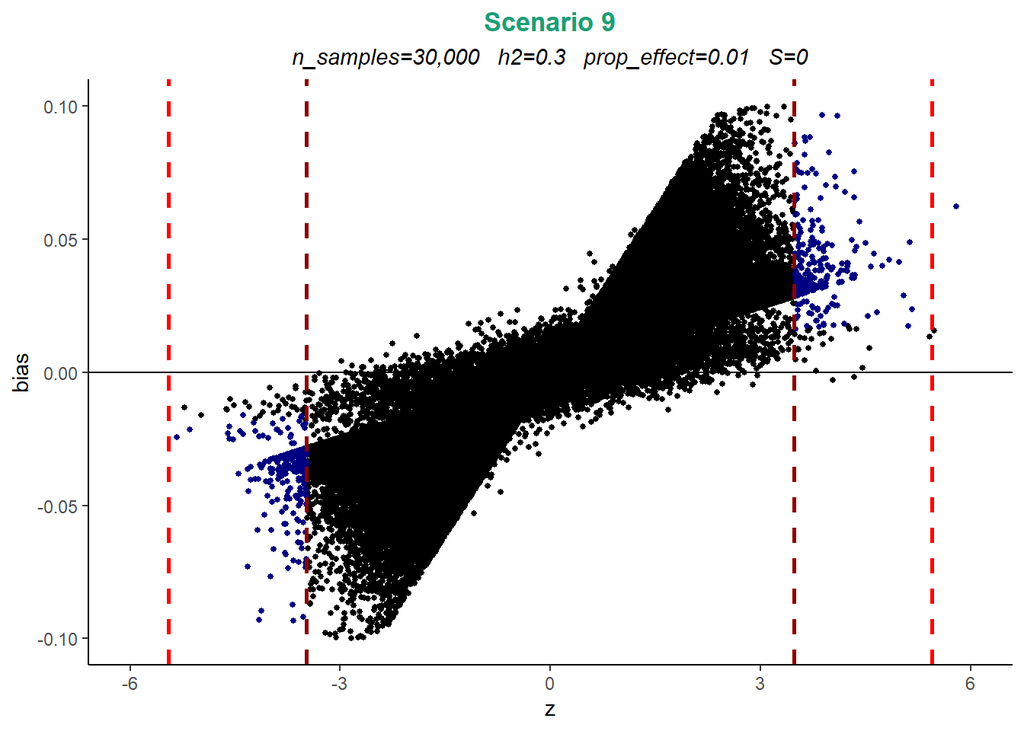

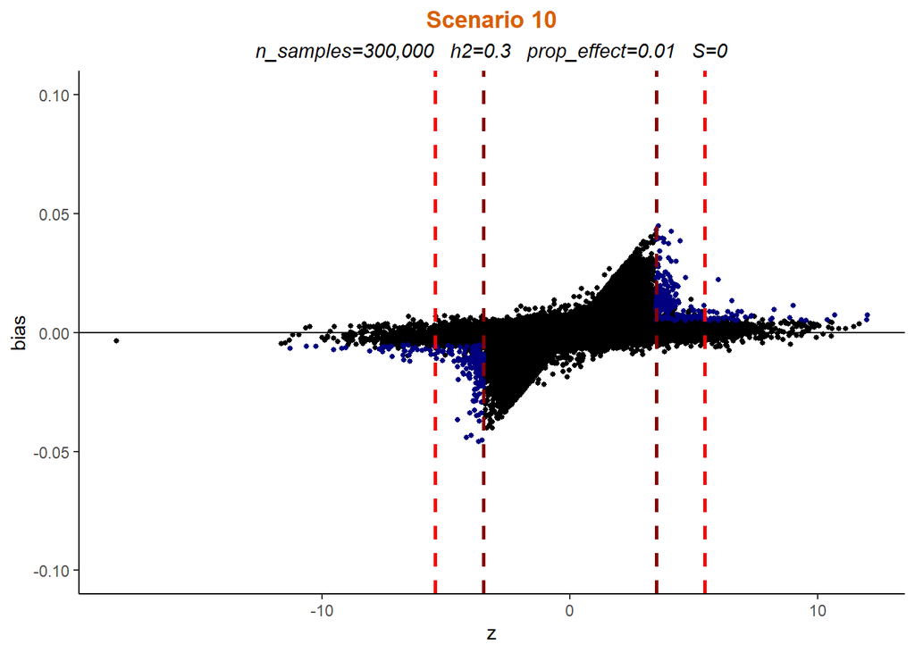

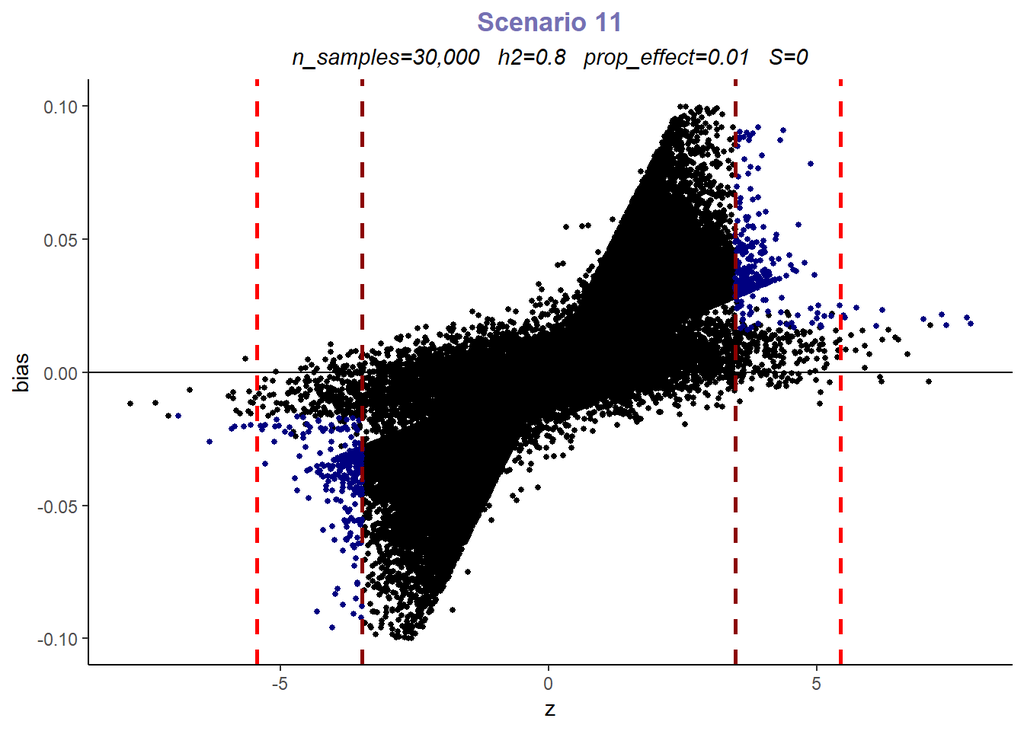

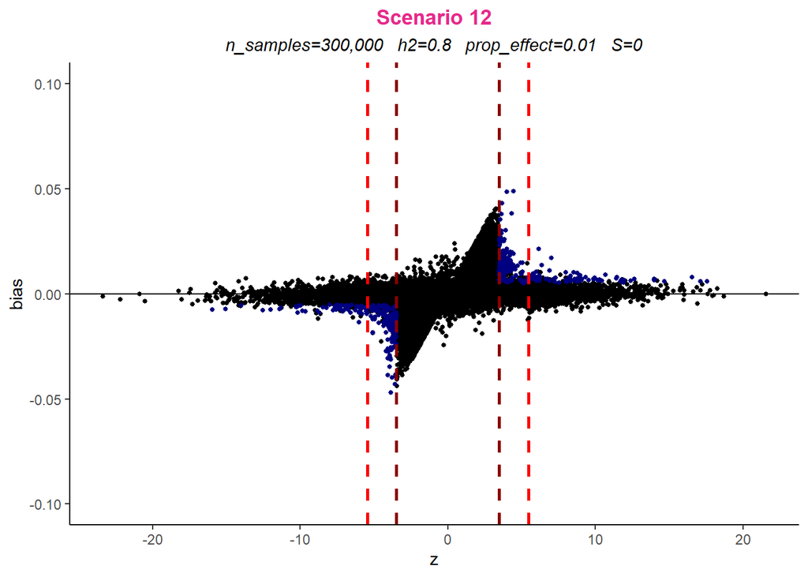

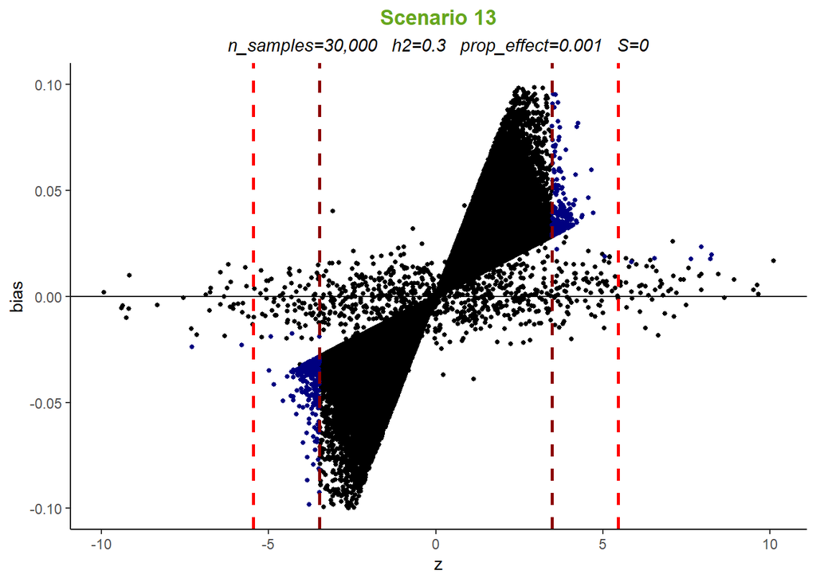

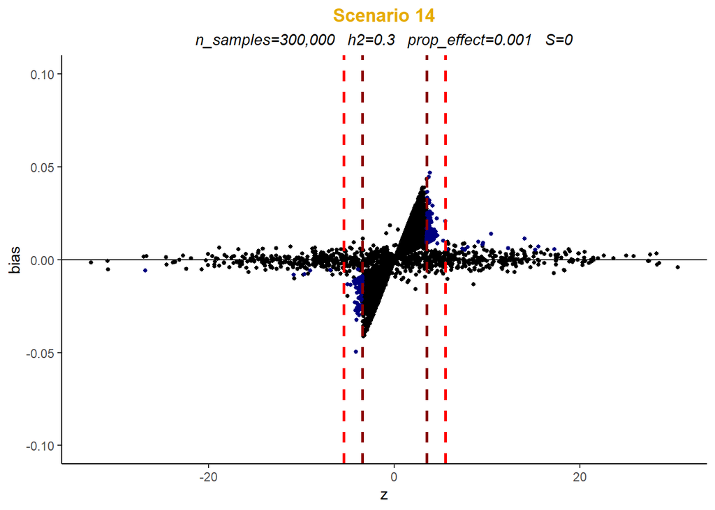

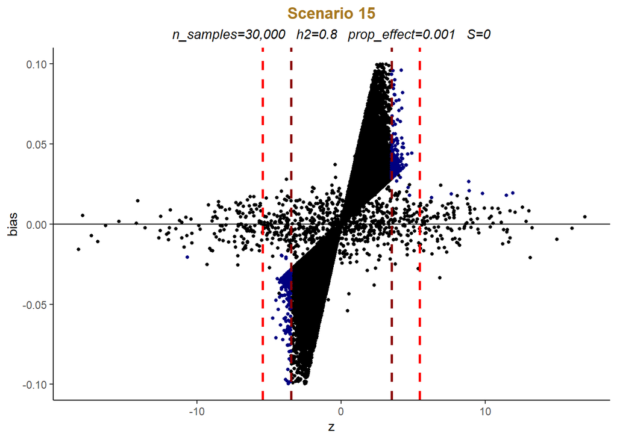

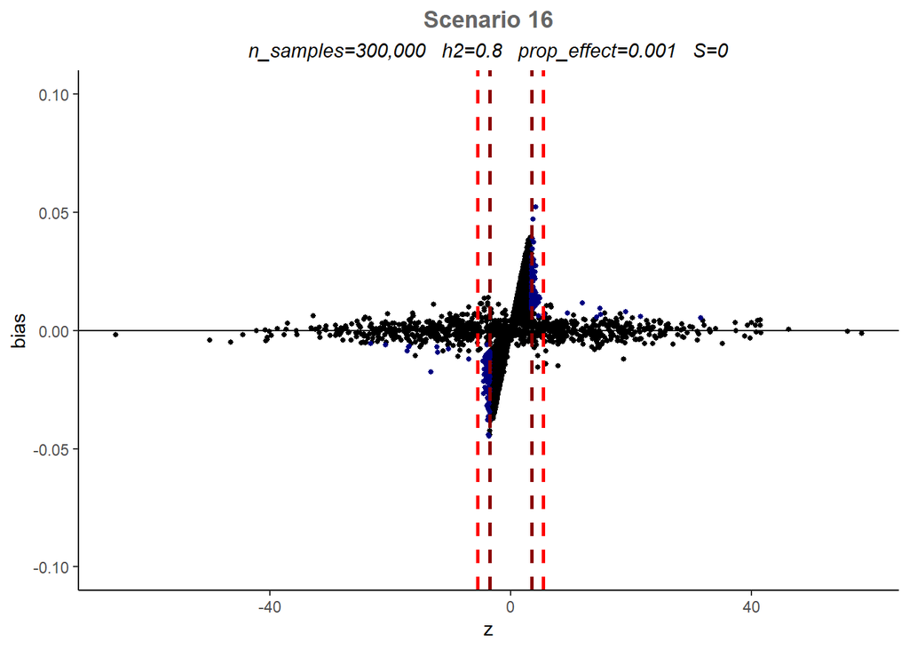

Next, over 100 simulations, we look at the number of significant SNPs, the proportion of these SNPs that have association estimates more extreme than their true effect size, the proportion of these SNPs which are *significantly* overestimated and the MSE of significant SNPs at two different thresholds; the common genome-wide significance threshold of $5 \times 10^{-8}$ and a higher threshold of $5 \times 10^{-4}$. Large values for the proportion of *significantly* overestimated SNPs and the MSE of significant SNPs provide evidence for a great degree of bias induced by Winner’s Curse.

Running the code provided in `nsig_prop_bias_100sim.R`, we obtain the following results:

| Scenario | n_samples | h2 | prop_effect | S | n_sig 5e-8 | prop_bias 5e-8 | prop_x 5e-8 | mse 5e-8 | n_sig 5e-4 | prop_bias 5e-4 | prop_x 5e-4 | mse 5e-4 | sd(n_sig) 5e-8 | sd(prop_bias) 5e-8 | sd(prop_x) 5e-8 | sd(mse) 5e-8 | sd(n_sig) 5e-4 | sd(prop_bias) 5e-4 | sd(prop_x) 5e-4 | sd(mse) 5e-4 |
| --- | --- | --- | --- | --- | --- | --- | --- | --- | --- | --- | --- | --- | --- | --- | --- | --- | --- | --- | --- | --- |
| 1 | 30,000 | 0.3 | 0.010 | -1 | 0.70 | 1.0000 | 0.9000 | 0.001573 | 611.08 | 0.9996 | 0.9155 | 0.001924 | 0.745 | 0.0000 | 0.2950 | 0.001234 | 22.974 | 0.0008 | 0.0098 | 0.000108 |
| 2 | 300,000 | 0.3 | 0.010 | -1 | 848.63 | 0.7619 | 0.0895 | 0.000022 | 3213.43 | 0.7485 | 0.2090 | 0.000049 | 18.145 | 0.0142 | 0.0103 | 0.000002 | 37.746 | 0.0065 | 0.0067 | 0.000002 |
| 3 | 30,000 | 0.8 | 0.010 | -1 | 31.85 | 0.9804 | 0.4020 | 0.000598 | 1090.14 | 0.9579 | 0.5655 | 0.001194 | 5.208 | 0.0280 | 0.0834 | 0.000198 | 29.233 | 0.0052 | 0.0138 | 0.000059 |
| 4 | 300,000 | 0.8 | 0.010 | -1 | 2760.68 | 0.6284 | 0.0484 | 0.000017 | 5359.92 | 0.6394 | 0.1299 | 0.000035 | 30.091 | 0.0084 | 0.0038 | 0.000001 | 50.643 | 0.0065 | 0.0044 | 0.000001 |
| 5 | 30,000 | 0.3 | 0.001 | -1 | 86.90 | 0.7591 | 0.0892 | 0.000214 | 768.32 | 0.8953 | 0.6724 | 0.001497 | 6.317 | 0.0437 | 0.0290 | 0.000054 | 20.931 | 0.0105 | 0.0120 | 0.000083 |
| 6 | 300,000 | 0.3 | 0.001 | -1 | 568.70 | 0.5509 | 0.0330 | 0.000016 | 1218.08 | 0.7323 | 0.4306 | 0.000100 | 14.074 | 0.0225 | 0.0078 | 0.000002 | 25.736 | 0.0120 | 0.0125 | 0.000006 |
| 7 | 30,000 | 0.8 | 0.001 | -1 | 276.26 | 0.6273 | 0.0464 | 0.000168 | 989.79 | 0.8045 | 0.5292 | 0.001203 | 10.413 | 0.0271 | 0.0123 | 0.000027 | 23.185 | 0.0116 | 0.0127 | 0.000076 |
| 8 | 300,000 | 0.8 | 0.001 | -1 | 727.10 | 0.5257 | 0.0287 | 0.000016 | 1321.72 | 0.7029 | 0.3940 | 0.000092 | 12.491 | 0.0171 | 0.0061 | 0.000001 | 23.077 | 0.0110 | 0.0115 | 0.000006 |
| 9 | 30,000 | 0.3 | 0.010 | 0 | 1.45 | 1.0000 | 0.8610 | 0.001661 | 627.30 | 0.9985 | 0.8924 | 0.001816 | 1.298 | 0.0000 | 0.2745 | 0.005559 | 25.147 | 0.0016 | 0.0109 | 0.000105 |
| 10 | 300,000 | 0.3 | 0.010 | 0 | 882.45 | 0.7297 | 0.0807 | 0.000012 | 3049.61 | 0.7424 | 0.2185 | 0.000047 | 18.435 | 0.0152 | 0.0098 | 0.000001 | 36.295 | 0.0077 | 0.0073 | 0.000003 |
| 11 | 30,000 | 0.8 | 0.010 | 0 | 48.06 | 0.9509 | 0.2908 | 0.000245 | 1119.09 | 0.9386 | 0.5397 | 0.001087 | 6.350 | 0.0301 | 0.0645 | 0.000050 | 29.144 | 0.0065 | 0.0123 | 0.000062 |
| 12 | 300,000 | 0.8 | 0.010 | 0 | 2586.78 | 0.6204 | 0.0477 | 0.000011 | 5030.84 | 0.6447 | 0.1384 | 0.000032 | 32.771 | 0.0096 | 0.0038 | 0.000000 | 51.334 | 0.0063 | 0.0047 | 0.000002 |
| 13 | 30,000 | 0.3 | 0.001 | 0 | 88.32 | 0.7254 | 0.0774 | 0.000116 | 755.02 | 0.8960 | 0.6838 | 0.001474 | 6.377 | 0.0480 | 0.0279 | 0.000025 | 25.026 | 0.0098 | 0.0112 | 0.000074 |
| 14 | 300,000 | 0.3 | 0.001 | 0 | 531.27 | 0.5560 | 0.0334 | 0.000012 | 1181.25 | 0.7406 | 0.4404 | 0.000101 | 12.431 | 0.0215 | 0.0074 | 0.000001 | 25.108 | 0.0125 | 0.0113 | 0.000005 |
| 15 | 30,000 | 0.8 | 0.001 | 0 | 257.44 | 0.6234 | 0.0473 | 0.000106 | 952.15 | 0.8132 | 0.5476 | 0.001214 | 8.936 | 0.0276 | 0.0120 | 0.000013 | 24.095 | 0.0117 | 0.0125 | 0.000065 |
| 16 | 300,000 | 0.8 | 0.001 | 0 | 691.46 | 0.5268 | 0.0301 | 0.000013 | 1296.93 | 0.7086 | 0.4023 | 0.000093 | 13.526 | 0.0185 | 0.0066 | 0.000001 | 24.419 | 0.0119 | 0.0109 | 0.000005 |
| 17 | 30,000 | 0.3 | 0.010 | 1 | 2.55 | 0.9941 | 0.7339 | 0.000610 | 638.42 | 0.9955 | 0.8632 | 0.001770 | 1.623 | 0.0405 | 0.3034 | 0.000674 | 22.931 | 0.0027 | 0.0140 | 0.000098 |
| 18 | 300,000 | 0.3 | 0.010 | 1 | 919.28 | 0.7031 | 0.0706 | 0.000010 | 2906.40 | 0.7324 | 0.2237 | 0.000046 | 15.799 | 0.0142 | 0.0079 | 0.000001 | 36.509 | 0.0075 | 0.0074 | 0.000002 |
| 19 | 30,000 | 0.8 | 0.010 | 1 | 68.13 | 0.9178 | 0.2410 | 0.000198 | 1150.11 | 0.9209 | 0.5220 | 0.001053 | 7.795 | 0.0370 | 0.0486 | 0.000087 | 30.368 | 0.0076 | 0.0135 | 0.000058 |
| 20 | 300,000 | 0.8 | 0.010 | 1 | 2433.27 | 0.6105 | 0.0462 | 0.000009 | 4631.78 | 0.6446 | 0.1465 | 0.000032 | 30.705 | 0.0107 | 0.0047 | 0.000000 | 47.841 | 0.0073 | 0.0052 | 0.000002 |
| 21 | 30,000 | 0.3 | 0.001 | 1 | 93.15 | 0.7056 | 0.0684 | 0.000096 | 741.19 | 0.8974 | 0.6964 | 0.001519 | 5.960 | 0.0428 | 0.0273 | 0.000015 | 25.503 | 0.0095 | 0.0124 | 0.000082 |
| 22 | 300,000 | 0.3 | 0.001 | 1 | 482.94 | 0.5516 | 0.0329 | 0.000009 | 1122.81 | 0.7501 | 0.4615 | 0.000102 | 12.742 | 0.0244 | 0.0072 | 0.000001 | 26.412 | 0.0129 | 0.0132 | 0.000006 |
| 23 | 30,000 | 0.8 | 0.001 | 1 | 244.29 | 0.6120 | 0.0448 | 0.000089 | 914.58 | 0.8198 | 0.5672 | 0.001239 | 9.237 | 0.0272 | 0.0142 | 0.000010 | 24.222 | 0.0123 | 0.0135 | 0.000072 |
| 24 | 300,000 | 0.8 | 0.001 | 1 | 632.74 | 0.5336 | 0.0294 | 0.000010 | 1243.49 | 0.7215 | 0.4206 | 0.000094 | 14.730 | 0.0194 | 0.0071 | 0.000001 | 29.346 | 0.0118 | 0.0130 | 0.000006 |

$~$ $~$ $~$

We show how the number of significant SNPs differs for the 8 different scenarios with $S=0$ at the significance threshold $5 \times 10^{-8}$:

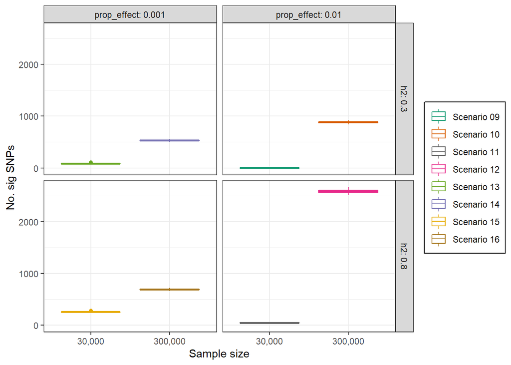

We can also visualise the proportion of SNPs that are *significantly* overestimated at the significance threshold of $5 \times 10^{-8}$ as follows:

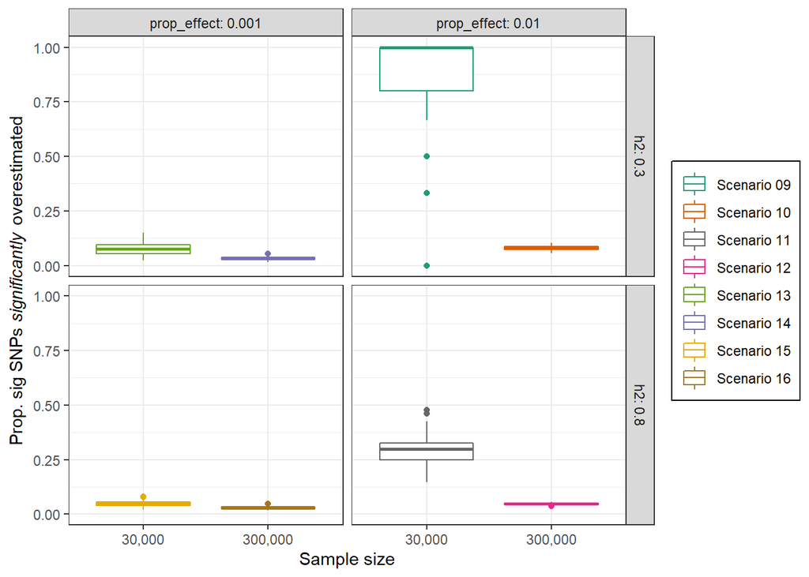

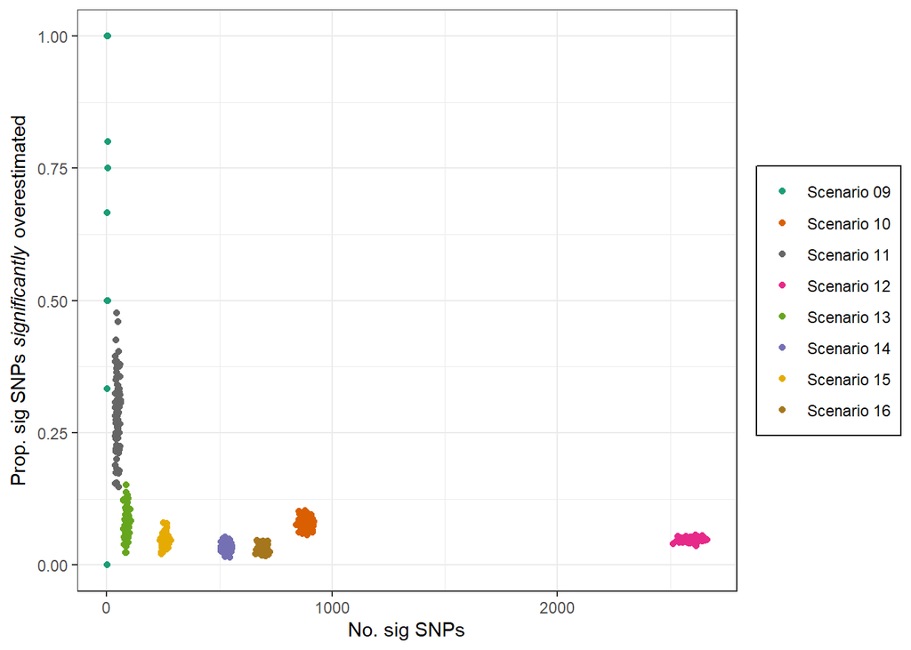

**Discussion:**

★ It is important to note here that for scenarios 1, 9 and 17, very few significant SNPs are detected on average. In some instances, we may even find that no SNPs are deemed significant at a threshold of $5 \times 10^{-8}$. We must keep this observation in mind going forward as we investigate the performance of methods under these three scenarios.

For both thresholds, the average number of significant SNPs increases as sample size increases, as expected. It also increases with heritability. However, the effect of changing `prop_effect` is more interesting. Decreasing the proportion of effect SNPs from 0.01 to 0.001 results in the number of significant SNPs increasing for a sample size of 30,000 while we witness the number of SNPs passing the genome-wide significance threshold decreasing for a larger sample size of 300,000.

Furthermore, increasing sample size and increasing heritability from 0.3 to 0.8 all tend to decrease the fraction of significant SNPs whose estimates are more extreme than their true effect size. Decreasing polygenicity from 0.01 to 0.001 also has this same effect at a significance threshold of $5 \times 10^{-8}$.

As sample size increases from 30,000 to 300,000 in all scenarios, `prop_x`, the proportion of significant SNPs which have been found to be significantly overestimated, decreases. This is a strong indicator that as the value of `n_samples` increases, we expect the bias induced by Winner’s Curse to be less of a problem among significant SNPs. However, this could also be due to the fact that as sample size increases, the number of significant SNPs passing the genome-wide significance threshold of `5e-8` also increases. This observation is also evident from the $z$ vs $\text{bias}$ plots in which we can see much smaller values of bias for the greater sample size of 300,000.

## Quantitative trait with normal effect size distribution

For this quantitative trait with a normal effect size distribution, using the code detailed in `winnerscurse_sims_ind.R`, we evaluated ten different Winner’s Curse methods across each of the 24 scenarios using the four previously detailed evaluation metrics. These methods include the three conditional likelihood methods, FDR Inverse Quantile Transformation `FIQT`, the bootstrap method `boot` as well as five variations of the empirical Bayes method, namely `EB`, `EB_df`, `EB_scam`, `EB_gam_po` and `EB_gam_nb`.

All results of the simulations are plotted in this instance for the scenarios in which $S$ is fixed at 0. These figures allow us to see more clearly the scenarios in which it would be beneficial to apply a Winner’s Curse correction method and also, provide us with a better indication of which method we should use.

A replication method which selects significant SNPs from a discovery GWAS and then uses a replication GWAS of the *same size* to obtain association estimates for these SNPs is also included in the plots. This can be viewed as acting as a form of benchmark for the other methods.

$~$ $~$

**Evaluation metric 1 with threshold** $5 \times 10^{-8}$:

Summary of results for `mse` contained in `norm_5e-8_100sim_ave.csv`:

| Scenario | n_samples | h2 | prop_effect | S | EB | EB_df | EB_scam | EB_gam_po | EB_gam_nb | FIQT | boot | cl1 | cl2 | cl3 | rep |
| --- | --- | --- | --- | --- | --- | --- | --- | --- | --- | --- | --- | --- | --- | --- | --- |
| 1 | 30,000 | 0.3 | 0.010 | -1 | -0.001602 | -0.001618 | -0.000714 | -0.001534 | -0.001555 | -0.001630 | -0.001581 | -0.001163 | -0.001514 | -0.001405 | -0.001608 |
| 2 | 300,000 | 0.3 | 0.010 | -1 | -0.000007 | -0.000006 | -0.000007 | 0.000015 | -0.000007 | 0.000000 | -0.000005 | 0.000052 | 0.000022 | 0.000034 | -0.000005 |
| 3 | 30,000 | 0.8 | 0.010 | -1 | -0.000432 | -0.000432 | -0.000419 | -0.000362 | -0.000363 | -0.000459 | -0.000467 | 0.000226 | -0.000313 | -0.000100 | -0.000455 |
| 4 | 300,000 | 0.8 | 0.010 | -1 | -0.000001 | 0.000006 | 0.000002 | 0.000001 | 0.000000 | 0.000005 | 0.000000 | 0.000034 | 0.000020 | 0.000025 | -0.000001 |
| 5 | 30,000 | 0.3 | 0.001 | -1 | -0.000048 | -0.000011 | -0.000055 | -0.000031 | -0.000036 | 0.000133 | 0.000068 | 0.000498 | 0.000225 | 0.000335 | -0.000059 |
| 6 | 300,000 | 0.3 | 0.001 | -1 | 0.000000 | 0.000038 | 0.000092 | 0.000022 | 0.000006 | 0.000010 | 0.000013 | 0.000016 | 0.000010 | 0.000012 | 0.000000 |
| 7 | 30,000 | 0.8 | 0.001 | -1 | -0.000004 | 0.000007 | 0.000032 | 0.000337 | -0.000003 | 0.000143 | 0.000147 | 0.000330 | 0.000191 | 0.000246 | -0.000015 |
| 8 | 300,000 | 0.8 | 0.001 | -1 | 0.000000 | 0.000045 | 0.000010 | 0.000079 | 0.000004 | 0.000007 | 0.000007 | 0.000008 | 0.000006 | 0.000007 | 0.000000 |
| 9 | 30,000 | 0.3 | 0.010 | 0 | -0.000698 | -0.000716 | -0.000313 | -0.000677 | -0.000678 | -0.000723 | -0.000697 | -0.000459 | -0.000668 | -0.000601 | -0.000748 |
| 10 | 300,000 | 0.3 | 0.010 | 0 | -0.000003 | -0.000002 | -0.000003 | 0.000005 | -0.000003 | 0.000000 | -0.000002 | 0.000026 | 0.000011 | 0.000017 | -0.000003 |
| 11 | 30,000 | 0.8 | 0.010 | 0 | -0.000157 | -0.000126 | -0.000153 | -0.000128 | -0.000130 | -0.000153 | -0.000162 | 0.000173 | -0.000078 | 0.000023 | -0.000169 |
| 12 | 300,000 | 0.8 | 0.010 | 0 | -0.000001 | 0.000006 | 0.000002 | 0.000002 | 0.000000 | 0.000002 | 0.000000 | 0.000021 | 0.000011 | 0.000015 | -0.000001 |
| 13 | 30,000 | 0.3 | 0.001 | 0 | -0.000024 | -0.000004 | -0.000027 | -0.000006 | -0.000007 | 0.000064 | 0.000033 | 0.000261 | 0.000112 | 0.000172 | -0.000034 |
| 14 | 300,000 | 0.3 | 0.001 | 0 | 0.000000 | 0.000037 | 0.000090 | 0.000023 | 0.000005 | 0.000007 | 0.000009 | 0.000015 | 0.000009 | 0.000011 | 0.000000 |
| 15 | 30,000 | 0.8 | 0.001 | 0 | -0.000005 | 0.000005 | 0.000072 | 0.000159 | -0.000001 | 0.000076 | 0.000099 | 0.000216 | 0.000115 | 0.000155 | -0.000012 |
| 16 | 300,000 | 0.8 | 0.001 | 0 | 0.000000 | 0.000045 | 0.000011 | 0.000093 | 0.000003 | 0.000006 | 0.000007 | 0.000010 | 0.000008 | 0.000008 | 0.000000 |
| 17 | 30,000 | 0.3 | 0.010 | 1 | -0.000520 | -0.000534 | -0.000299 | -0.000530 | -0.000529 | -0.000555 | -0.000512 | -0.000315 | -0.000527 | -0.000459 | -0.000562 |
| 18 | 300,000 | 0.3 | 0.010 | 1 | -0.000002 | -0.000001 | -0.000001 | 0.000004 | -0.000002 | 0.000001 | 0.000000 | 0.000022 | 0.000011 | 0.000015 | -0.000002 |
| 19 | 30,000 | 0.8 | 0.010 | 1 | -0.000114 | -0.000062 | -0.000108 | -0.000099 | -0.000102 | -0.000095 | -0.000107 | 0.000219 | -0.000013 | 0.000081 | -0.000123 |
| 20 | 300,000 | 0.8 | 0.010 | 1 | -0.000001 | 0.000007 | 0.000003 | 0.000003 | 0.000001 | 0.000002 | 0.000000 | 0.000016 | 0.000009 | 0.000012 | -0.000001 |
| 21 | 30,000 | 0.3 | 0.001 | 1 | -0.000016 | 0.000002 | -0.000021 | 0.000014 | -0.000001 | 0.000066 | 0.000038 | 0.000212 | 0.000096 | 0.000143 | -0.000032 |
| 22 | 300,000 | 0.3 | 0.001 | 1 | 0.000000 | 0.000032 | 0.000080 | 0.000023 | 0.000003 | 0.000006 | 0.000008 | 0.000011 | 0.000007 | 0.000008 | -0.000001 |
| 23 | 30,000 | 0.8 | 0.001 | 1 | -0.000001 | 0.000011 | 0.000143 | 0.000132 | 0.000007 | 0.000071 | 0.000103 | 0.000161 | 0.000091 | 0.000118 | -0.000009 |
| 24 | 300,000 | 0.8 | 0.001 | 1 | 0.000001 | 0.000033 | 0.000011 | 0.000080 | 0.000002 | 0.000005 | 0.000005 | 0.000008 | 0.000005 | 0.000006 | 0.000000 |

$~$ $~$ $~$ $~$

The *mean* change in MSE over all significant SNPs across the 24 scenarios is obtained for each method:

```
##            EB         EB_df       EB_scam     EB_gam_po     EB_gam_nb
## -1.514583e-04 -1.349167e-04 -6.550000e-05 -9.895833e-05 -1.410833e-04
##          FIQT          boot           cl1           cl2           cl3
## -1.254583e-04 -1.248333e-04  2.491667e-05 -8.975000e-05 -4.675000e-05
##           rep
## -1.600000e-04
```

The methods are ranked according to the results above in ascending order:

```
##        EB     EB_df   EB_scam EB_gam_po EB_gam_nb      FIQT      boot       cl1
##         2         4         9         7         3         5         6        11
##       cl2       cl3       rep
##         8        10         1
```

$~$ $~$ $~$ $~$

*Change* in MSE over all significant SNPs due to method implementation, using a significance threshold of $5 \times 10^{-8}$:

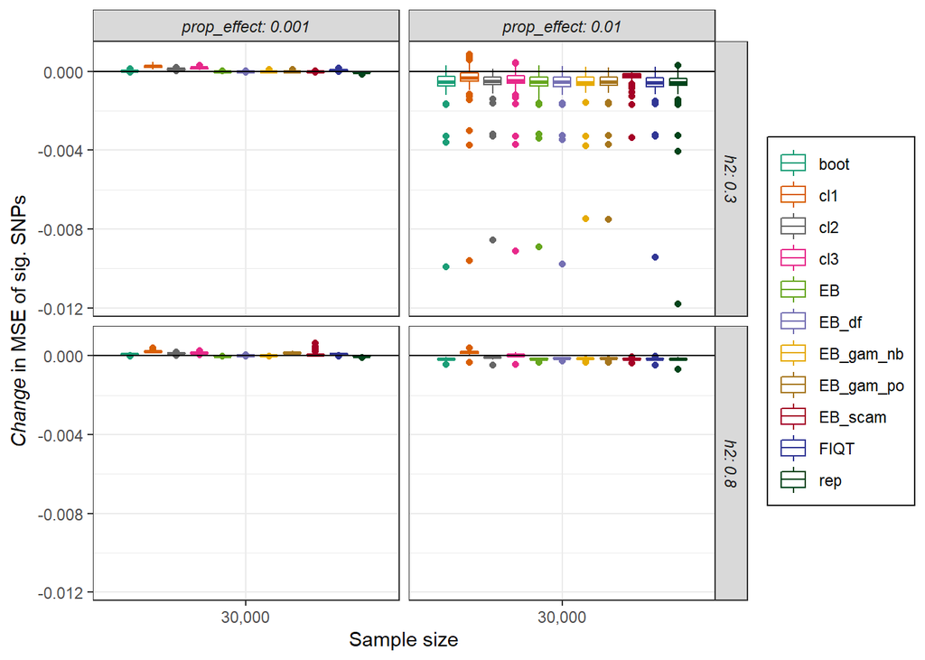

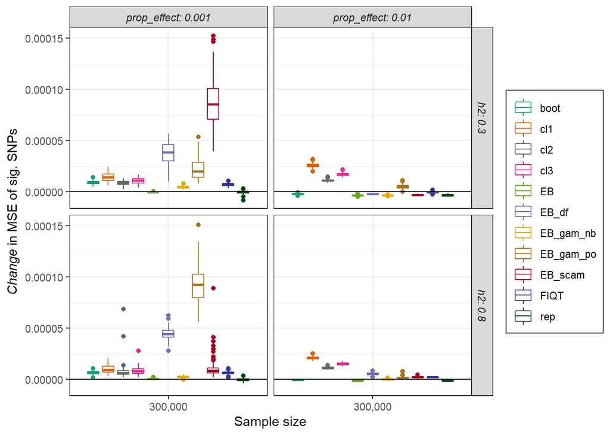

$~$ $~$ $~$ $~$

**Evaluation metric 2 with threshold** $5 \times 10^{-8}$:

Summary of results for `rmse` contained in `norm_5e-8_100sim_ave.csv`:

| Scenario | n_samples | h2 | prop_effect | S | EB | EB_df | EB_scam | EB_gam_po | EB_gam_nb | FIQT | boot | cl1 | cl2 | cl3 | rep |
| --- | --- | --- | --- | --- | --- | --- | --- | --- | --- | --- | --- | --- | --- | --- | --- |
| 1 | 30,000 | 0.3 | 0.010 | -1 | -0.027445 | -0.027790 | -0.010603 | -0.026142 | -0.026244 | -0.028553 | -0.025815 | -0.017651 | -0.025608 | -0.022277 | -0.028338 |
| 2 | 300,000 | 0.3 | 0.010 | -1 | -0.000770 | -0.000715 | -0.000773 | 0.001367 | -0.000831 | -0.000053 | -0.000526 | 0.003921 | 0.001974 | 0.002827 | -0.000637 |
| 3 | 30,000 | 0.8 | 0.010 | -1 | -0.011428 | -0.011434 | -0.010981 | -0.009048 | -0.009071 | -0.012488 | -0.012780 | 0.004013 | -0.007484 | -0.002191 | -0.012255 |
| 4 | 300,000 | 0.8 | 0.010 | -1 | -0.000183 | 0.000731 | 0.000232 | 0.000124 | -0.000013 | 0.000565 | 0.000004 | 0.003039 | 0.001962 | 0.002412 | -0.000094 |
| 5 | 30,000 | 0.3 | 0.001 | -1 | -0.001757 | -0.000406 | -0.002013 | -0.001128 | -0.001324 | 0.004011 | 0.002159 | 0.011913 | 0.006306 | 0.008741 | -0.002152 |
| 6 | 300,000 | 0.3 | 0.001 | -1 | 0.000015 | 0.003334 | 0.006356 | 0.002132 | 0.000709 | 0.001127 | 0.001363 | 0.001639 | 0.001114 | 0.001325 | -0.000024 |
| 7 | 30,000 | 0.8 | 0.001 | -1 | -0.000162 | 0.000274 | 0.000947 | 0.009334 | -0.000114 | 0.004682 | 0.004785 | 0.009311 | 0.005993 | 0.007381 | -0.000604 |
| 8 | 300,000 | 0.8 | 0.001 | -1 | 0.000059 | 0.003828 | 0.001052 | 0.005741 | 0.000419 | 0.000768 | 0.000753 | 0.000928 | 0.000668 | 0.000760 | -0.000037 |
| 9 | 30,000 | 0.3 | 0.010 | 0 | -0.016988 | -0.017592 | -0.006473 | -0.016893 | -0.016694 | -0.018129 | -0.016315 | -0.008511 | -0.016430 | -0.013188 | -0.018280 |
| 10 | 300,000 | 0.3 | 0.010 | 0 | -0.000499 | -0.000311 | -0.000438 | 0.000688 | -0.000509 | -0.000022 | -0.000305 | 0.002736 | 0.001356 | 0.001959 | -0.000508 |
| 11 | 30,000 | 0.8 | 0.010 | 0 | -0.006294 | -0.004766 | -0.006079 | -0.004850 | -0.004931 | -0.006022 | -0.006507 | 0.004795 | -0.002675 | 0.000736 | -0.006872 |
| 12 | 300,000 | 0.8 | 0.010 | 0 | -0.000167 | 0.000763 | 0.000325 | 0.000245 | 0.000010 | 0.000316 | -0.000061 | 0.002352 | 0.001425 | 0.001816 | -0.000182 |
| 13 | 30,000 | 0.3 | 0.001 | 0 | -0.001140 | -0.000180 | -0.001339 | -0.000293 | -0.000351 | 0.002634 | 0.001442 | 0.008585 | 0.004306 | 0.006173 | -0.001706 |
| 14 | 300,000 | 0.3 | 0.001 | 0 | -0.000009 | 0.003549 | 0.006602 | 0.002415 | 0.000616 | 0.000920 | 0.001182 | 0.001698 | 0.001113 | 0.001352 | -0.000035 |
| 15 | 30,000 | 0.8 | 0.001 | 0 | -0.000237 | 0.000228 | 0.002600 | 0.005949 | -0.000021 | 0.003195 | 0.004023 | 0.007599 | 0.004555 | 0.005850 | -0.000580 |
| 16 | 300,000 | 0.8 | 0.001 | 0 | 0.000064 | 0.003986 | 0.001230 | 0.006643 | 0.000346 | 0.000791 | 0.000826 | 0.001197 | 0.000908 | 0.000996 | -0.000061 |
| 17 | 30,000 | 0.3 | 0.010 | 1 | -0.014158 | -0.014740 | -0.007031 | -0.014788 | -0.014752 | -0.015848 | -0.013634 | -0.006852 | -0.014218 | -0.011304 | -0.015856 |
| 18 | 300,000 | 0.3 | 0.010 | 1 | -0.000339 | -0.000146 | -0.000236 | 0.000535 | -0.000326 | 0.000227 | -0.000058 | 0.002553 | 0.001404 | 0.001897 | -0.000338 |
| 19 | 30,000 | 0.8 | 0.010 | 1 | -0.005033 | -0.002453 | -0.004660 | -0.004187 | -0.004336 | -0.003941 | -0.004600 | 0.006383 | -0.000440 | 0.002667 | -0.005427 |
| 20 | 300,000 | 0.8 | 0.010 | 1 | -0.000118 | 0.001059 | 0.000484 | 0.000519 | 0.000122 | 0.000368 | 0.000009 | 0.002025 | 0.001264 | 0.001579 | -0.000137 |
| 21 | 30,000 | 0.3 | 0.001 | 1 | -0.000830 | 0.000212 | -0.000996 | 0.000653 | 0.000002 | 0.002939 | 0.001828 | 0.007610 | 0.004039 | 0.005566 | -0.001528 |
| 22 | 300,000 | 0.3 | 0.001 | 1 | 0.000006 | 0.003323 | 0.006340 | 0.002617 | 0.000520 | 0.000815 | 0.001088 | 0.001450 | 0.000932 | 0.001145 | -0.000085 |
| 23 | 30,000 | 0.8 | 0.001 | 1 | -0.000070 | 0.000571 | 0.005092 | 0.005355 | 0.000341 | 0.003213 | 0.004406 | 0.006330 | 0.003949 | 0.004942 | -0.000508 |
| 24 | 300,000 | 0.8 | 0.001 | 1 | 0.000079 | 0.003411 | 0.001285 | 0.006295 | 0.000240 | 0.000653 | 0.000710 | 0.001118 | 0.000724 | 0.000882 | -0.000025 |

$~$ $~$ $~$ $~$

The *mean* change in RMSE over all significant SNPs across the 24 scenarios is obtained for each method:

```
##            EB         EB_df       EB_scam     EB_gam_po     EB_gam_nb
## -0.0036418333 -0.0023026667 -0.0007948750 -0.0011132083 -0.0031746667
##          FIQT          boot           cl1           cl2           cl3
## -0.0024096667 -0.0023342917  0.0024242083 -0.0009526250  0.0005019167
##           rep
## -0.0040112083
```

The methods are ranked according to the results above in ascending order:

```
##        EB     EB_df   EB_scam EB_gam_po EB_gam_nb      FIQT      boot       cl1
##         2         6         9         7         3         4         5        11
##       cl2       cl3       rep
##         8        10         1
```

$~$ $~$ $~$ $~$

*Change* in RMSE over all significant SNPs due to method implementation, using a significance threshold of $5 \times 10^{-8}$:

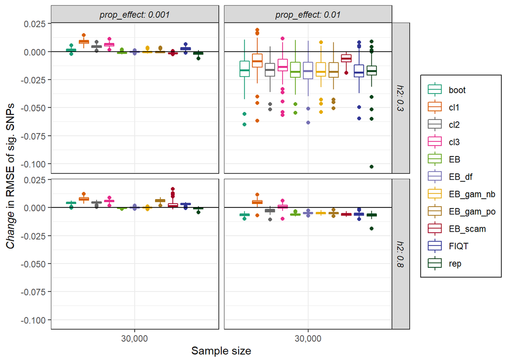

[figure not shown]

$~$ $~$ $~$ $~$

**Evaluation metric 3 with threshold** $5 \times 10^{-8}$:

Summary of results for `rel_mse` contained in `norm_5e-8_100sim_ave.csv`:

| Scenario | n_samples | h2 | prop_effect | S | EB | EB_df | EB_scam | EB_gam_po | EB_gam_nb | FIQT | boot | cl1 | cl2 | cl3 | rep |
| --- | --- | --- | --- | --- | --- | --- | --- | --- | --- | --- | --- | --- | --- | --- | --- |
| 1 | 30,000 | 0.3 | 0.010 | -1 | -0.8362 | -0.8309 | -0.4905 | -0.8273 | -0.8320 | -0.8677 | -0.7836 | -0.4084 | -0.8405 | -0.6896 | -0.8554 |
| 2 | 300,000 | 0.3 | 0.010 | -1 | -0.3046 | -0.2849 | -0.3057 | 0.6971 | -0.3269 | -0.0184 | -0.2128 | 2.4396 | 1.0474 | 1.6138 | -0.2537 |
| 3 | 30,000 | 0.8 | 0.010 | -1 | -0.7141 | -0.7128 | -0.6839 | -0.6014 | -0.6028 | -0.7342 | -0.7505 | 0.4352 | -0.4875 | -0.1217 | -0.7381 |
| 4 | 300,000 | 0.8 | 0.010 | -1 | -0.0880 | 0.3939 | 0.1191 | 0.0643 | -0.0059 | 0.2986 | 0.0023 | 2.0593 | 1.2016 | 1.5423 | -0.0437 |
| 5 | 30,000 | 0.3 | 0.001 | -1 | -0.2205 | -0.0507 | -0.2489 | -0.1393 | -0.1641 | 0.7473 | 0.3885 | 2.5203 | 1.1580 | 1.7086 | -0.2312 |
| 6 | 300,000 | 0.3 | 0.001 | -1 | 0.0081 | 2.4379 | 5.8957 | 1.4184 | 0.3931 | 0.6553 | 0.8129 | 1.0162 | 0.6488 | 0.7921 | -0.0027 |
| 7 | 30,000 | 0.8 | 0.001 | -1 | -0.0218 | 0.0489 | 0.1953 | 2.0727 | -0.0133 | 0.8849 | 0.9104 | 2.0245 | 1.1785 | 1.5151 | -0.0741 |
| 8 | 300,000 | 0.8 | 0.001 | -1 | 0.0302 | 2.8874 | 0.6477 | 5.0707 | 0.2242 | 0.4281 | 0.4195 | 0.5332 | 0.3784 | 0.4276 | -0.0111 |
| 9 | 30,000 | 0.3 | 0.010 | 0 | -0.6882 | -0.6913 | -0.4345 | -0.7137 | -0.7048 | -0.7518 | -0.6247 | -0.1029 | -0.7452 | -0.5022 | -0.7938 |
| 10 | 300,000 | 0.3 | 0.010 | 0 | -0.2707 | -0.1740 | -0.2396 | 0.4521 | -0.2761 | -0.0106 | -0.1696 | 2.2580 | 0.9589 | 1.4861 | -0.2740 |
| 11 | 30,000 | 0.8 | 0.010 | 0 | -0.6436 | -0.5165 | -0.6241 | -0.5232 | -0.5306 | -0.6104 | -0.6522 | 0.7735 | -0.2921 | 0.1358 | -0.6758 |
| 12 | 300,000 | 0.8 | 0.010 | 0 | -0.1003 | 0.5272 | 0.2117 | 0.1610 | 0.0065 | 0.2045 | -0.0366 | 1.9753 | 1.0710 | 1.4325 | -0.1079 |
| 13 | 30,000 | 0.3 | 0.001 | 0 | -0.1919 | -0.0259 | -0.2287 | -0.0375 | -0.0474 | 0.6061 | 0.3244 | 2.3262 | 1.0143 | 1.5459 | -0.2704 |
| 14 | 300,000 | 0.3 | 0.001 | 0 | -0.0053 | 3.2621 | 7.8374 | 2.0031 | 0.4023 | 0.6245 | 0.8298 | 1.2762 | 0.7769 | 0.9730 | -0.0122 |
| 15 | 30,000 | 0.8 | 0.001 | 0 | -0.0425 | 0.0518 | 0.6953 | 1.5353 | 0.0008 | 0.7444 | 0.9684 | 2.0817 | 1.1136 | 1.5032 | -0.0956 |
| 16 | 300,000 | 0.8 | 0.001 | 0 | 0.0369 | 3.4753 | 0.8719 | 7.1857 | 0.2047 | 0.4939 | 0.5180 | 0.7939 | 0.6011 | 0.6457 | -0.0278 |
| 17 | 30,000 | 0.3 | 0.010 | 1 | -0.7182 | -0.7263 | -0.4769 | -0.7628 | -0.7586 | -0.8070 | -0.6579 | -0.1967 | -0.7825 | -0.5683 | -0.8215 |
| 18 | 300,000 | 0.3 | 0.010 | 1 | -0.2060 | -0.0919 | -0.1450 | 0.3822 | -0.1988 | 0.1540 | -0.0354 | 2.3315 | 1.1170 | 1.6027 | -0.2048 |
| 19 | 30,000 | 0.8 | 0.010 | 1 | -0.5935 | -0.3209 | -0.5560 | -0.5093 | -0.5244 | -0.4750 | -0.5444 | 1.2099 | -0.0339 | 0.4711 | -0.6191 |
| 20 | 300,000 | 0.8 | 0.010 | 1 | -0.0773 | 0.8402 | 0.3523 | 0.3862 | 0.0841 | 0.2625 | 0.0063 | 1.8215 | 1.0291 | 1.3413 | -0.0891 |
| 21 | 30,000 | 0.3 | 0.001 | 1 | -0.1553 | 0.0677 | -0.1803 | 0.1748 | 0.0286 | 0.7386 | 0.4512 | 2.2487 | 1.0568 | 1.5364 | -0.2343 |
| 22 | 300,000 | 0.3 | 0.001 | 1 | 0.0039 | 3.4129 | 8.4411 | 2.4750 | 0.3683 | 0.6018 | 0.8353 | 1.1696 | 0.6992 | 0.8855 | -0.0471 |
| 23 | 30,000 | 0.8 | 0.001 | 1 | -0.0131 | 0.1288 | 1.5923 | 1.4915 | 0.0766 | 0.8074 | 1.1639 | 1.8143 | 1.0223 | 1.3369 | -0.0964 |
| 24 | 300,000 | 0.8 | 0.001 | 1 | 0.0515 | 3.3173 | 1.1027 | 7.9409 | 0.1583 | 0.4571 | 0.5005 | 0.8374 | 0.5116 | 0.6386 | -0.0110 |

$~$ $~$ $~$ $~$

```
##         EB      EB_df    EB_scam  EB_gam_po  EB_gam_nb       FIQT       boot
## -0.2400208  0.6843875  0.9728500  1.2248542 -0.1265917  0.1847458  0.1526542
##        cl1        cl2        cl3        rep
##  1.3849167  0.5584500  0.8855167 -0.2746167
```

The methods are ranked according to the results above in ascending order:

```
##        EB     EB_df   EB_scam EB_gam_po EB_gam_nb      FIQT      boot       cl1
##         2         7         9        10         3         5         4        11
##       cl2       cl3       rep
##         6         8         1
```

$~$ $~$ $~$ $~$

*Relative change* in MSE over all significant SNPs due to method implementation, using a significance threshold of $5 \times 10^{-8}$:

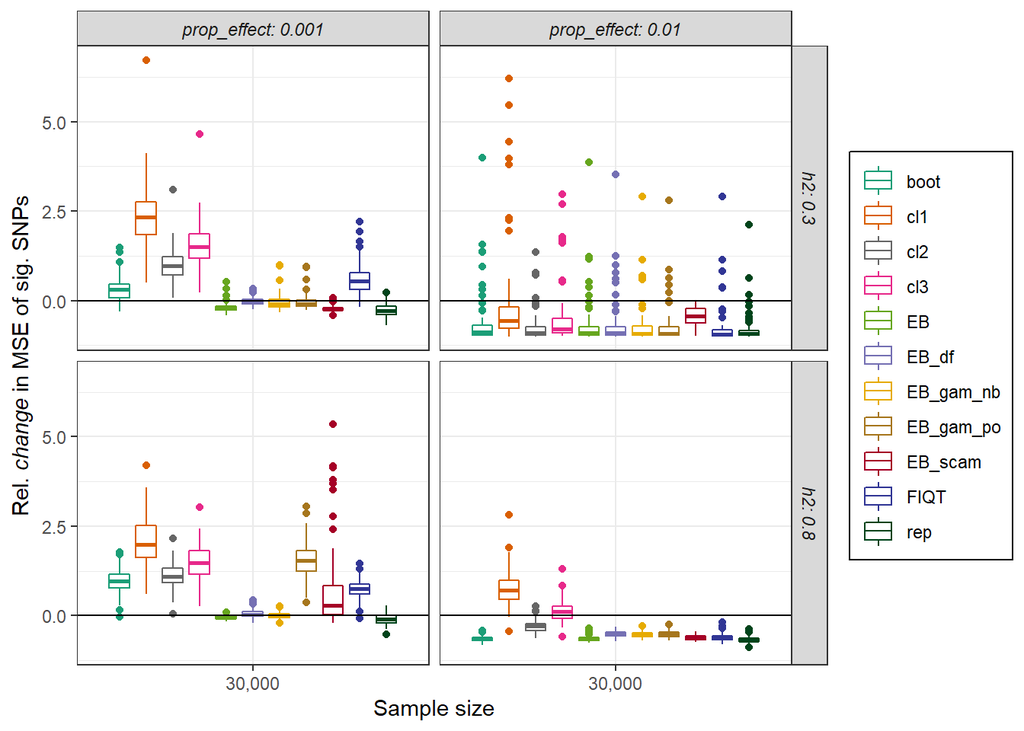

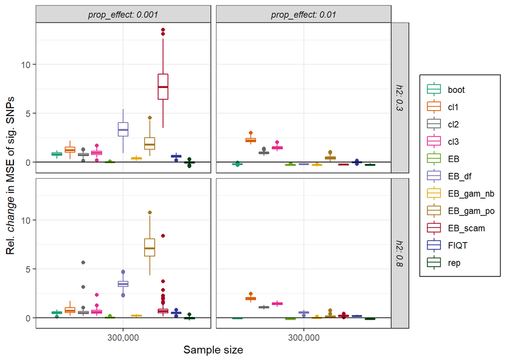

$~$ $~$ $~$ $~$

**Evaluation metric 4 with threshold** $5 \times 10^{-8}$:

Summary of results for `flb` contained in `norm_5e-8_100sim_ave.csv`:

| Scenario | n_samples | h2 | prop_effect | S | EB | EB_df | EB_scam | EB_gam_po | EB_gam_nb | FIQT | boot | cl1 | cl2 | cl3 | rep |
| --- | --- | --- | --- | --- | --- | --- | --- | --- | --- | --- | --- | --- | --- | --- | --- |
| 1 | 30,000 | 0.3 | 0.010 | -1 | 0.9818 | 0.9636 | 1.0000 | 0.9818 | 0.9758 | 0.9636 | 0.9576 | 0.9030 | 0.9818 | 0.9303 | 0.9636 |
| 2 | 300,000 | 0.3 | 0.010 | -1 | 0.6383 | 0.6661 | 0.6573 | 0.3559 | 0.6538 | 0.5077 | 0.6029 | 0.5313 | 0.5018 | 0.5132 | 0.5582 |
| 3 | 30,000 | 0.8 | 0.010 | -1 | 0.9096 | 0.9034 | 0.8650 | 0.9301 | 0.9298 | 0.7759 | 0.7957 | 0.6135 | 0.7390 | 0.6646 | 0.8338 |
| 4 | 300,000 | 0.8 | 0.010 | -1 | 0.5622 | 0.2175 | 0.5562 | 0.2965 | 0.4898 | 0.4404 | 0.5308 | 0.5158 | 0.4848 | 0.4995 | 0.5090 |
| 5 | 30,000 | 0.3 | 0.001 | -1 | 0.6268 | 0.3024 | 0.6674 | 0.5398 | 0.5757 | 0.4167 | 0.4831 | 0.5303 | 0.4966 | 0.5116 | 0.5675 |
| 6 | 300,000 | 0.3 | 0.001 | -1 | 0.3704 | 0.1452 | 0.3191 | 0.1885 | 0.3268 | 0.3825 | 0.2772 | 0.5111 | 0.4802 | 0.5031 | 0.5000 |
| 7 | 30,000 | 0.8 | 0.001 | -1 | 0.4662 | 0.3970 | 0.5620 | 0.2215 | 0.4805 | 0.3765 | 0.3032 | 0.5159 | 0.4870 | 0.5010 | 0.5137 |
| 8 | 300,000 | 0.8 | 0.001 | -1 | 0.3339 | 0.1544 | 0.4380 | 0.1196 | 0.3634 | 0.3895 | 0.2991 | 0.5041 | 0.4750 | 0.4994 | 0.5009 |
| 9 | 30,000 | 0.3 | 0.010 | 0 | 0.8943 | 0.8699 | 1.0000 | 0.8852 | 0.9035 | 0.9096 | 0.8567 | 0.7703 | 0.9217 | 0.8628 | 0.9431 |
| 10 | 300,000 | 0.3 | 0.010 | 0 | 0.6197 | 0.5320 | 0.6493 | 0.3653 | 0.6381 | 0.4872 | 0.5771 | 0.5301 | 0.4988 | 0.5105 | 0.5469 |
| 11 | 30,000 | 0.8 | 0.010 | 0 | 0.8554 | 0.8935 | 0.7999 | 0.8640 | 0.8676 | 0.6840 | 0.7179 | 0.5920 | 0.6580 | 0.6175 | 0.7594 |
| 12 | 300,000 | 0.8 | 0.010 | 0 | 0.5565 | 0.2297 | 0.5163 | 0.2818 | 0.4869 | 0.4377 | 0.5236 | 0.5132 | 0.4835 | 0.4982 | 0.5116 |
| 13 | 30,000 | 0.3 | 0.001 | 0 | 0.5920 | 0.2806 | 0.6382 | 0.4446 | 0.4524 | 0.3992 | 0.4592 | 0.5320 | 0.4955 | 0.5088 | 0.5434 |
| 14 | 300,000 | 0.3 | 0.001 | 0 | 0.3706 | 0.1442 | 0.2921 | 0.1704 | 0.3405 | 0.3818 | 0.2789 | 0.5071 | 0.4758 | 0.4997 | 0.5009 |
| 15 | 30,000 | 0.8 | 0.001 | 0 | 0.4557 | 0.3598 | 0.5257 | 0.2378 | 0.4048 | 0.3692 | 0.2850 | 0.5141 | 0.4829 | 0.4994 | 0.5061 |
| 16 | 300,000 | 0.8 | 0.001 | 0 | 0.3366 | 0.1569 | 0.4210 | 0.1122 | 0.3784 | 0.3828 | 0.3045 | 0.4995 | 0.4741 | 0.4944 | 0.5030 |
| 17 | 30,000 | 0.3 | 0.010 | 1 | 0.8867 | 0.8721 | 0.9931 | 0.9087 | 0.9173 | 0.9234 | 0.8756 | 0.7295 | 0.9319 | 0.8155 | 0.9464 |
| 18 | 300,000 | 0.3 | 0.010 | 1 | 0.5995 | 0.3749 | 0.6404 | 0.3546 | 0.6177 | 0.4636 | 0.5379 | 0.5223 | 0.4909 | 0.5037 | 0.5346 |
| 19 | 30,000 | 0.8 | 0.010 | 1 | 0.7942 | 0.8190 | 0.7597 | 0.7998 | 0.8044 | 0.6250 | 0.6711 | 0.5588 | 0.5990 | 0.5660 | 0.7036 |
| 20 | 300,000 | 0.8 | 0.010 | 1 | 0.5505 | 0.2309 | 0.4909 | 0.2733 | 0.4695 | 0.4339 | 0.5173 | 0.5137 | 0.4842 | 0.4996 | 0.5128 |
| 21 | 30,000 | 0.3 | 0.001 | 1 | 0.5739 | 0.2773 | 0.6267 | 0.3580 | 0.4120 | 0.3876 | 0.4347 | 0.5269 | 0.4924 | 0.5070 | 0.5468 |
| 22 | 300,000 | 0.3 | 0.001 | 1 | 0.3708 | 0.1462 | 0.2632 | 0.1604 | 0.3522 | 0.3821 | 0.2807 | 0.5053 | 0.4783 | 0.4972 | 0.5036 |
| 23 | 30,000 | 0.8 | 0.001 | 1 | 0.4326 | 0.3149 | 0.4768 | 0.2234 | 0.3664 | 0.3667 | 0.2680 | 0.5105 | 0.4826 | 0.4962 | 0.5080 |
| 24 | 300,000 | 0.8 | 0.001 | 1 | 0.3340 | 0.1620 | 0.4050 | 0.1063 | 0.3863 | 0.3852 | 0.3103 | 0.5063 | 0.4774 | 0.5011 | 0.5007 |

$~$ $~$ $~$ $~$

```
##        EB     EB_df   EB_scam EB_gam_po EB_gam_nb      FIQT      boot       cl1
## 0.5880083 0.4338958 0.6068042 0.4241458 0.5664000 0.5113250 0.5061708 0.5606917
##       cl2       cl3       rep
## 0.5655500 0.5625125 0.6049000
```

The methods are ranked according to the results above in descending order:

```
##        EB     EB_df   EB_scam EB_gam_po EB_gam_nb      FIQT      boot       cl1
##         3        10         1        11         4         8         9         7
##       cl2       cl3       rep
##         5         6         2
```

$~$ $~$ $~$ $~$

Fraction of significant SNPs with improved association estimates due to method implementation, using a significance threshold of $5 \times 10^{-8}$:

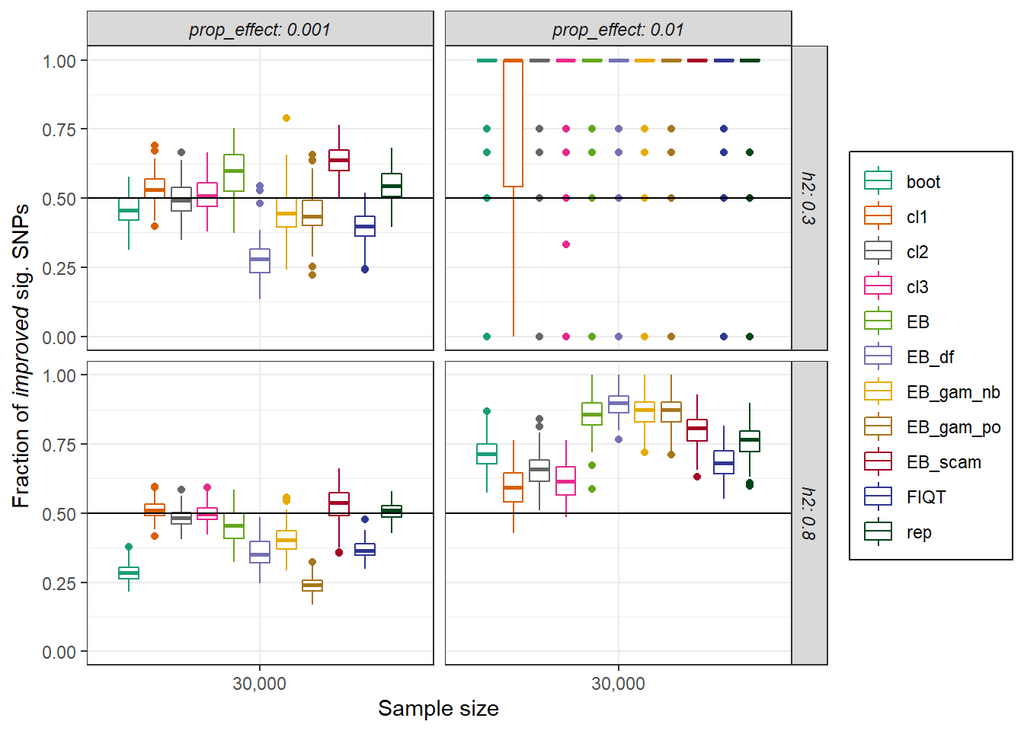

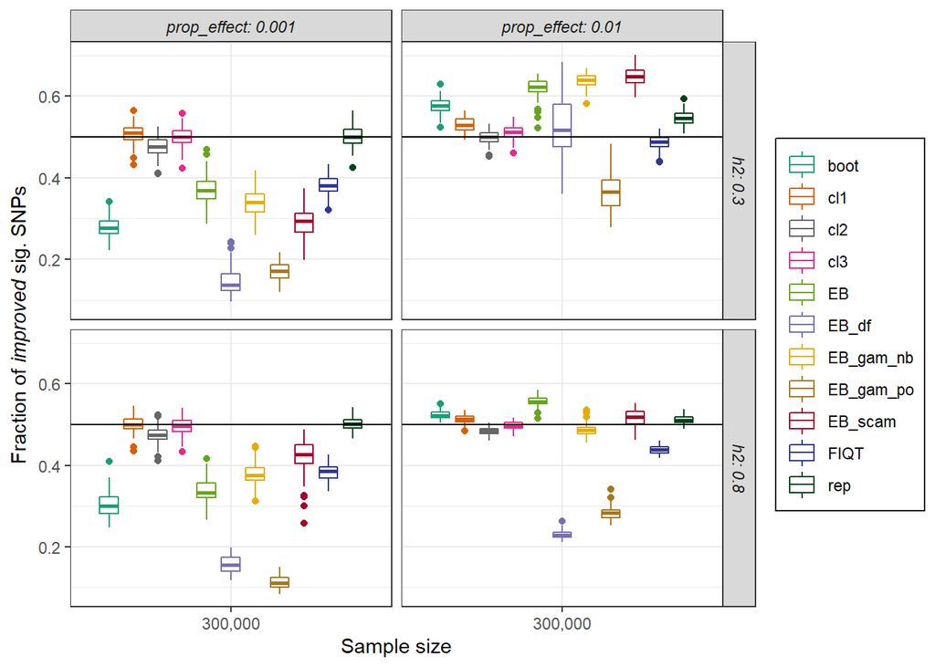

$~$ $~$ $~$ $~$

**Evaluation metric 1 with threshold** $5 \times 10^{-4}$:

Summary of results for `mse` contained in `norm_5e-4_100sim_ave.csv`:

| Scenario | n_samples | h2 | prop_effect | S | EB | EB_df | EB_scam | EB_gam_po | EB_gam_nb | FIQT | boot | cl1 | cl2 | cl3 | rep |
| --- | --- | --- | --- | --- | --- | --- | --- | --- | --- | --- | --- | --- | --- | --- | --- |
| 1 | 30,000 | 0.3 | 0.010 | -1 | -0.001814 | -0.001814 | -0.001807 | -0.001814 | -0.001814 | -0.001815 | -0.001706 | -0.001587 | -0.001340 | -0.001506 | -0.001751 |
| 2 | 300,000 | 0.3 | 0.010 | -1 | -0.000020 | -0.000018 | -0.000019 | -0.000009 | -0.000019 | -0.000012 | -0.000014 | -0.000011 | -0.000018 | -0.000016 | -0.000034 |
| 3 | 30,000 | 0.8 | 0.010 | -1 | -0.000901 | -0.000902 | -0.000900 | -0.000894 | -0.000894 | -0.000882 | -0.000874 | -0.000813 | -0.000782 | -0.000831 | -0.001035 |
| 4 | 300,000 | 0.8 | 0.010 | -1 | -0.000010 | 0.000011 | 0.000003 | -0.000004 | -0.000005 | -0.000002 | -0.000006 | -0.000004 | -0.000007 | -0.000007 | -0.000019 |
| 5 | 30,000 | 0.3 | 0.001 | -1 | -0.001206 | -0.001172 | -0.001189 | -0.001175 | -0.001181 | -0.001152 | -0.001081 | -0.001135 | -0.000964 | -0.001083 | -0.001326 |
| 6 | 300,000 | 0.3 | 0.001 | -1 | -0.000075 | -0.000047 | -0.000018 | -0.000059 | -0.000044 | -0.000066 | -0.000055 | -0.000072 | -0.000060 | -0.000068 | -0.000083 |
| 7 | 30,000 | 0.8 | 0.001 | -1 | -0.000914 | -0.000844 | -0.000839 | -0.000743 | -0.000831 | -0.000826 | -0.000751 | -0.000875 | -0.000740 | -0.000834 | -0.001041 |
| 8 | 300,000 | 0.8 | 0.001 | -1 | -0.000069 | -0.000028 | -0.000047 | -0.000023 | -0.000019 | -0.000063 | -0.000053 | -0.000068 | -0.000056 | -0.000063 | -0.000077 |
| 9 | 30,000 | 0.3 | 0.010 | 0 | -0.001735 | -0.001735 | -0.001734 | -0.001736 | -0.001737 | -0.001741 | -0.001614 | -0.001521 | -0.001267 | -0.001433 | -0.001667 |
| 10 | 300,000 | 0.3 | 0.010 | 0 | -0.000024 | -0.000023 | -0.000023 | -0.000020 | -0.000023 | -0.000021 | -0.000021 | -0.000021 | -0.000023 | -0.000023 | -0.000036 |
| 11 | 30,000 | 0.8 | 0.010 | 0 | -0.000868 | -0.000873 | -0.000874 | -0.000873 | -0.000873 | -0.000872 | -0.000831 | -0.000813 | -0.000727 | -0.000797 | -0.000968 |
| 12 | 300,000 | 0.8 | 0.010 | 0 | -0.000012 | 0.000003 | -0.000004 | -0.000008 | -0.000009 | -0.000008 | -0.000010 | -0.000009 | -0.000011 | -0.000011 | -0.000021 |
| 13 | 30,000 | 0.3 | 0.001 | 0 | -0.001294 | -0.001271 | -0.001268 | -0.001267 | -0.001267 | -0.001265 | -0.001165 | -0.001189 | -0.000996 | -0.001125 | -0.001348 |
| 14 | 300,000 | 0.3 | 0.001 | 0 | -0.000077 | -0.000050 | -0.000023 | -0.000061 | -0.000043 | -0.000071 | -0.000059 | -0.000074 | -0.000062 | -0.000070 | -0.000087 |
| 15 | 30,000 | 0.8 | 0.001 | 0 | -0.000983 | -0.000922 | -0.000894 | -0.000884 | -0.000891 | -0.000926 | -0.000836 | -0.000926 | -0.000779 | -0.000879 | -0.001072 |
| 16 | 300,000 | 0.8 | 0.001 | 0 | -0.000068 | -0.000026 | -0.000046 | -0.000013 | -0.000017 | -0.000063 | -0.000053 | -0.000068 | -0.000056 | -0.000064 | -0.000078 |
| 17 | 30,000 | 0.3 | 0.010 | 1 | -0.001668 | -0.001670 | -0.001673 | -0.001674 | -0.001675 | -0.001680 | -0.001554 | -0.001469 | -0.001226 | -0.001386 | -0.001622 |
| 18 | 300,000 | 0.3 | 0.010 | 1 | -0.000025 | -0.000024 | -0.000025 | -0.000022 | -0.000024 | -0.000022 | -0.000022 | -0.000024 | -0.000024 | -0.000025 | -0.000037 |
| 19 | 30,000 | 0.8 | 0.010 | 1 | -0.000825 | -0.000835 | -0.000832 | -0.000829 | -0.000829 | -0.000828 | -0.000786 | -0.000783 | -0.000693 | -0.000764 | -0.000932 |
| 20 | 300,000 | 0.8 | 0.010 | 1 | -0.000014 | -0.000001 | -0.000008 | -0.000009 | -0.000011 | -0.000011 | -0.000012 | -0.000013 | -0.000014 | -0.000014 | -0.000023 |
| 21 | 30,000 | 0.3 | 0.001 | 1 | -0.001335 | -0.001306 | -0.001303 | -0.001310 | -0.001296 | -0.001308 | -0.001200 | -0.001218 | -0.001014 | -0.001148 | -0.001371 |
| 22 | 300,000 | 0.3 | 0.001 | 1 | -0.000083 | -0.000062 | -0.000037 | -0.000069 | -0.000042 | -0.000078 | -0.000065 | -0.000079 | -0.000066 | -0.000075 | -0.000090 |
| 23 | 30,000 | 0.8 | 0.001 | 1 | -0.001059 | -0.000999 | -0.000953 | -0.000971 | -0.000944 | -0.001006 | -0.000900 | -0.000985 | -0.000820 | -0.000929 | -0.001114 |
| 24 | 300,000 | 0.8 | 0.001 | 1 | -0.000074 | -0.000036 | -0.000051 | -0.000030 | -0.000017 | -0.000070 | -0.000058 | -0.000072 | -0.000060 | -0.000068 | -0.000083 |

$~$ $~$ $~$ $~$

The *mean* change in MSE over all significant SNPs across the 24 scenarios is obtained for each method:

```
##            EB         EB_df       EB_scam     EB_gam_po     EB_gam_nb
## -0.0006313750 -0.0006101667 -0.0006068333 -0.0006040417 -0.0006043750
##          FIQT          boot           cl1           cl2           cl3
## -0.0006161667 -0.0005719167 -0.0005762083 -0.0004918750 -0.0005507917
##           rep
## -0.0006631250
```

The methods are ranked according to the results above in ascending order:

```
##        EB     EB_df   EB_scam EB_gam_po EB_gam_nb      FIQT      boot       cl1
##         2         4         5         7         6         3         9         8
##       cl2       cl3       rep
##        11        10         1
```

$~$ $~$ $~$ $~$

*Change* in MSE over all significant SNPs due to method implementation, using a significance threshold of $5 \times 10^{-4}$:

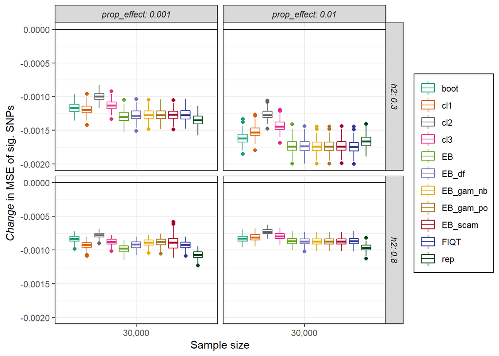

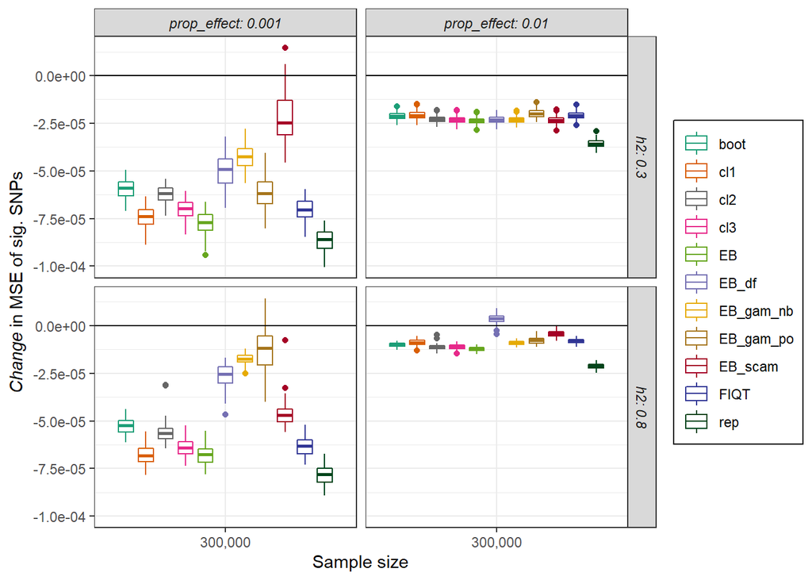

$~$ $~$ $~$ $~$

**Discussion:**

It is worth noting from the above simulations how the Winner’s Curse methods tend to break down, or equivalently, no longer make improvements based on the first evaluation metric, `rmse` when the proportion of effect SNPs is 0.001. This is a measure of polygenicity. That said, both the original empirical Bayes method and the variation of the empirical Bayes method which uses the `gam` function and a negative binomial distribution of counts perform very similar to just taking a replication estimate when the replication sample is of the same size as the discovery GWAS, i.e. `n_samples` is equivalent in both data sets. Under the assumption that SNPs are independent, this observation *strongly supports the use of empirical Bayes or empirical Bayes* `gam-nb` as Winner’s Curse adjustment methods, particularly when a replication GWAS is not available. The consistency of these two methods is what makes them stand out above the other considered methods. Unlike the bootstrap, FIQT and other variations of the empirical Bayes method, it is rare that it will result in an increase in the relative MSE or MSE over all significant SNPs. For that reason, employing these methods gives us confidence that we have not adjusted our estimated effect sizes so that they are now less accurate, regardless of the underlying genetic architecture or number of samples. It is surprising to see the empirical Bayes method which uses two shape constrained additive models (SCAMs) perform extremely poorly when the sample size is 300,000 and the proportion of effect SNPs 0.001. This method was seen to perform well with real data.

For `prop_effect = 0.01`, our proposed bootstrap method for summary statistics performs in a comparable manner to both empirical Bayes and the replication method. However, the bootstrap method ceases to perform as well at obtaining less biased association estimates when the proportion of effect SNPs is reduced to 0.001. That said, it is still seen to perform competitively with respect to other currently published methods.

Clearly, even though we also look at using a significance threshold of $5 \times 10^{-4}$, it is the genome-wide significance threshold of $5 \times 10^{-8}$ that is of most interest to us as using the higher threshold of $5 \times 10^{-4}$ often results in the detection of many false positives.

At the $5 \times 10^{-4}$ threshold, we see that all methods result in a negative change in MSE as desired for sample sizes of 30,000. However, as mentioned above, we must bear in mind that when using this lower threshold, we risk capturing SNPs which in fact have no effect, i.e. they have a true effect size of 0 and are false positives. Thus, as all of these methods may be to some degree considered as ‘shrinkage’ methods, it is expected that we would see an improvement in the MSE over all significant SNPs. The approach of obtaining replication estimates clearly outperforms all methods. However, it is still the original empirical Bayes method that seems to be second best. For the larger sample size of 300,000, it is worth noting that the other four variations of the empirical Bayes method do not seem to perform well compared to other methods, with a positive value for change in MSE noted in some cases. When the proportion of effect SNPs is 0.001, `EB_gam_nb` is not behaving as well as seen previously.

## Quantitative trait with bimodal effect size distribution

Similar to above, to provide us with an idea of what this bimodal distribution looks like, we look at the $z$ vs $\text{bias}$ plot for Scenarios 11 and 12.

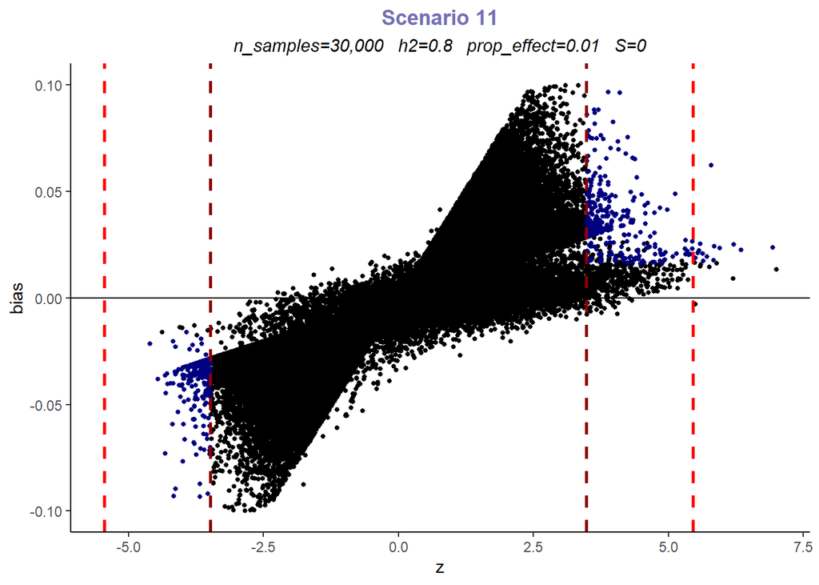

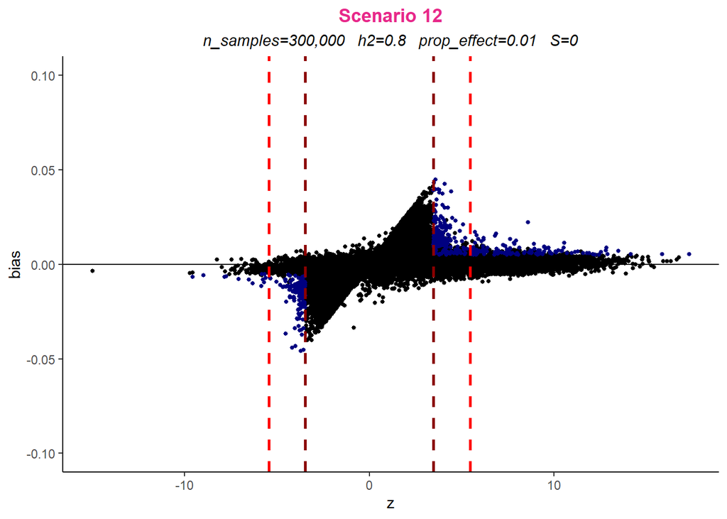

$~$ $~$

Next, the process of describing the results illustrated in the previous section using the first bias evaluation metric, `mse` with significance thresholds of $5 \times 10^{-8}$ and $5 \times 10^{-4}$, is repeated.

**Evaluation metric 1 with threshold** $5 \times 10^{-8}$:

Summary of results for `mse` contained in `bim_5e-8_50sim_ave.csv`:

| Scenario | n_samples | h2 | prop_effect | S | EB | FIQT | boot | cl1 | cl2 | cl3 | rep |
| --- | --- | --- | --- | --- | --- | --- | --- | --- | --- | --- | --- |
| 1 | 30,000 | 0.3 | 0.010 | -1 | -0.001218 | -0.001209 | -0.001241 | -0.001017 | -0.001119 | -0.001106 | -0.001267 |
| 2 | 300,000 | 0.3 | 0.010 | -1 | -0.000007 | -0.000003 | -0.000006 | 0.000038 | 0.000014 | 0.000024 | -0.000006 |
| 3 | 30,000 | 0.8 | 0.010 | -1 | -0.000376 | -0.000401 | -0.000408 | -0.000006 | -0.000322 | -0.000200 | -0.000386 |
| 4 | 300,000 | 0.8 | 0.010 | -1 | -0.000002 | 0.000003 | -0.000001 | 0.000030 | 0.000018 | 0.000022 | -0.000001 |
| 5 | 30,000 | 0.3 | 0.001 | -1 | -0.000041 | 0.000048 | -0.000006 | 0.000395 | 0.000143 | 0.000246 | -0.000052 |
| 6 | 300,000 | 0.3 | 0.001 | -1 | 0.000000 | 0.000009 | 0.000010 | 0.000015 | 0.000009 | 0.000011 | 0.000000 |
| 7 | 30,000 | 0.8 | 0.001 | -1 | -0.000011 | 0.000101 | 0.000084 | 0.000289 | 0.000157 | 0.000210 | -0.000013 |
| 8 | 300,000 | 0.8 | 0.001 | -1 | 0.000000 | 0.000007 | 0.000009 | 0.000009 | 0.000006 | 0.000007 | 0.000000 |
| 9 | 30,000 | 0.3 | 0.010 | 0 | -0.000921 | -0.000903 | -0.000910 | -0.000717 | -0.000852 | -0.000826 | -0.000913 |
| 10 | 300,000 | 0.3 | 0.010 | 0 | -0.000005 | -0.000002 | -0.000004 | 0.000030 | 0.000012 | 0.000019 | -0.000003 |
| 11 | 30,000 | 0.8 | 0.010 | 0 | -0.000353 | -0.000380 | -0.000385 | -0.000044 | -0.000314 | -0.000211 | -0.000359 |
| 12 | 300,000 | 0.8 | 0.010 | 0 | -0.000001 | 0.000002 | -0.000001 | 0.000021 | 0.000012 | 0.000015 | -0.000001 |
| 13 | 30,000 | 0.3 | 0.001 | 0 | -0.000039 | 0.000043 | -0.000016 | 0.000295 | 0.000113 | 0.000187 | -0.000043 |
| 14 | 300,000 | 0.3 | 0.001 | 0 | 0.000000 | 0.000007 | 0.000006 | 0.000014 | 0.000009 | 0.000011 | -0.000001 |
| 15 | 30,000 | 0.8 | 0.001 | 0 | -0.000007 | 0.000076 | 0.000054 | 0.000206 | 0.000125 | 0.000153 | -0.000012 |
| 16 | 300,000 | 0.8 | 0.001 | 0 | 0.000000 | 0.000006 | 0.000007 | 0.000011 | 0.000009 | 0.000009 | 0.000000 |
| 17 | 30,000 | 0.3 | 0.010 | 1 | -0.001463 | -0.001404 | -0.001495 | -0.001257 | -0.001326 | -0.001348 | -0.001512 |
| 18 | 300,000 | 0.3 | 0.010 | 1 | -0.000006 | -0.000004 | -0.000006 | 0.000030 | 0.000011 | 0.000019 | -0.000004 |
| 19 | 30,000 | 0.8 | 0.010 | 1 | -0.000377 | -0.000426 | -0.000422 | -0.000112 | -0.000369 | -0.000272 | -0.000387 |
| 20 | 300,000 | 0.8 | 0.010 | 1 | -0.000001 | 0.000002 | -0.000001 | 0.000021 | 0.000012 | 0.000016 | -0.000001 |
| 21 | 30,000 | 0.3 | 0.001 | 1 | -0.000050 | 0.000023 | -0.000027 | 0.000309 | 0.000113 | 0.000194 | -0.000040 |
| 22 | 300,000 | 0.3 | 0.001 | 1 | 0.000000 | 0.000007 | 0.000007 | 0.000013 | 0.000008 | 0.000010 | -0.000001 |
| 23 | 30,000 | 0.8 | 0.001 | 1 | -0.000006 | 0.000080 | 0.000048 | 0.000208 | 0.000131 | 0.000159 | -0.000007 |
| 24 | 300,000 | 0.8 | 0.001 | 1 | 0.000000 | 0.000007 | 0.000007 | 0.000010 | 0.000007 | 0.000008 | 0.000000 |

$~$ $~$ $~$ $~$

The *mean* change in MSE over all significant SNPs across the 24 scenarios is obtained for each method:

```
##            EB          FIQT          boot           cl1           cl2
## -0.0002035000 -0.0001796250 -0.0001957083 -0.0000503750 -0.0001413750
##           cl3           rep
## -0.0001101250 -0.0002087083
```

The methods are ranked according to the results above in ascending order:

```
##   EB FIQT boot  cl1  cl2  cl3  rep
##    2    4    3    7    5    6    1
```

$~$ $~$ $~$ $~$

*Change* in MSE over all significant SNPs due to method implementation, using a significance threshold of $5 \times 10^{-8}$:

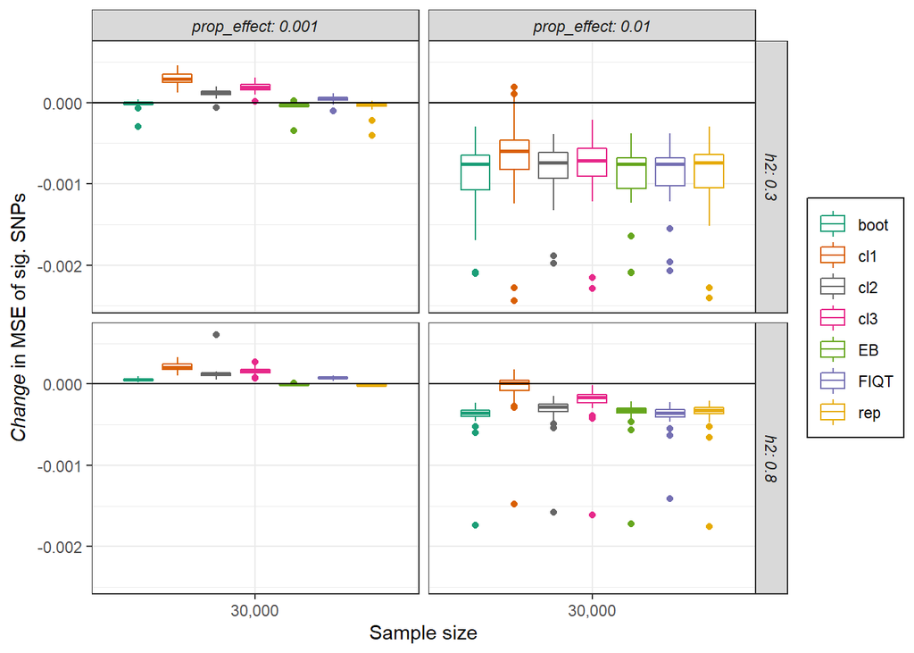

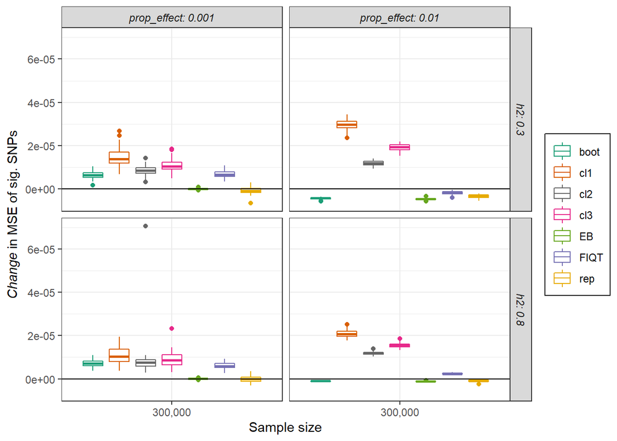

$~$ $~$ $~$ $~$

**Evaluation metric 1 with threshold** $5 \times 10^{-4}$:

Summary of results for `mse` contained in `bim_5e-4_50sim_ave.csv`:

| Scenario | n_samples | h2 | prop_effect | S | EB | FIQT | boot | cl1 | cl2 | cl3 | rep |
| --- | --- | --- | --- | --- | --- | --- | --- | --- | --- | --- | --- |
| 1 | 30,000 | 0.3 | 0.010 | -1 | -0.001841 | -0.001843 | -0.001717 | -0.001600 | -0.001335 | -0.001509 | -0.001753 |
| 2 | 300,000 | 0.3 | 0.010 | -1 | -0.000023 | -0.000016 | -0.000020 | -0.000013 | -0.000019 | -0.000018 | -0.000033 |
| 3 | 30,000 | 0.8 | 0.010 | -1 | -0.000959 | -0.000928 | -0.000926 | -0.000844 | -0.000779 | -0.000842 | -0.001021 |
| 4 | 300,000 | 0.8 | 0.010 | -1 | -0.000011 | -0.000003 | -0.000007 | -0.000004 | -0.000008 | -0.000007 | -0.000020 |
| 5 | 30,000 | 0.3 | 0.001 | -1 | -0.001208 | -0.001167 | -0.001110 | -0.001122 | -0.000951 | -0.001068 | -0.001304 |
| 6 | 300,000 | 0.3 | 0.001 | -1 | -0.000077 | -0.000067 | -0.000059 | -0.000073 | -0.000061 | -0.000069 | -0.000085 |
| 7 | 30,000 | 0.8 | 0.001 | -1 | -0.000906 | -0.000824 | -0.000768 | -0.000856 | -0.000727 | -0.000818 | -0.001020 |
| 8 | 300,000 | 0.8 | 0.001 | -1 | -0.000071 | -0.000064 | -0.000053 | -0.000069 | -0.000057 | -0.000064 | -0.000077 |
| 9 | 30,000 | 0.3 | 0.010 | 0 | -0.001842 | -0.001846 | -0.001712 | -0.001603 | -0.001329 | -0.001507 | -0.001745 |
| 10 | 300,000 | 0.3 | 0.010 | 0 | -0.000025 | -0.000018 | -0.000023 | -0.000018 | -0.000020 | -0.000020 | -0.000033 |
| 11 | 30,000 | 0.8 | 0.010 | 0 | -0.000953 | -0.000918 | -0.000910 | -0.000837 | -0.000752 | -0.000822 | -0.000992 |
| 12 | 300,000 | 0.8 | 0.010 | 0 | -0.000013 | -0.000007 | -0.000011 | -0.000008 | -0.000010 | -0.000010 | -0.000020 |
| 13 | 30,000 | 0.3 | 0.001 | 0 | -0.001291 | -0.001238 | -0.001178 | -0.001172 | -0.000983 | -0.001109 | -0.001334 |
| 14 | 300,000 | 0.3 | 0.001 | 0 | -0.000079 | -0.000070 | -0.000064 | -0.000074 | -0.000062 | -0.000070 | -0.000086 |
| 15 | 30,000 | 0.8 | 0.001 | 0 | -0.000971 | -0.000889 | -0.000842 | -0.000896 | -0.000753 | -0.000850 | -0.001036 |
| 16 | 300,000 | 0.8 | 0.001 | 0 | -0.000072 | -0.000064 | -0.000056 | -0.000068 | -0.000056 | -0.000064 | -0.000079 |
| 17 | 30,000 | 0.3 | 0.010 | 1 | -0.001849 | -0.001853 | -0.001716 | -0.001604 | -0.001330 | -0.001508 | -0.001745 |
| 18 | 300,000 | 0.3 | 0.010 | 1 | -0.000024 | -0.000016 | -0.000022 | -0.000015 | -0.000018 | -0.000018 | -0.000031 |
| 19 | 30,000 | 0.8 | 0.010 | 1 | -0.000969 | -0.000941 | -0.000929 | -0.000851 | -0.000765 | -0.000836 | -0.000996 |
| 20 | 300,000 | 0.8 | 0.010 | 1 | -0.000014 | -0.000007 | -0.000012 | -0.000008 | -0.000010 | -0.000010 | -0.000020 |
| 21 | 30,000 | 0.3 | 0.001 | 1 | -0.001252 | -0.001188 | -0.001140 | -0.001135 | -0.000951 | -0.001075 | -0.001291 |
| 22 | 300,000 | 0.3 | 0.001 | 1 | -0.000086 | -0.000077 | -0.000071 | -0.000080 | -0.000066 | -0.000075 | -0.000092 |
| 23 | 30,000 | 0.8 | 0.001 | 1 | -0.000977 | -0.000888 | -0.000859 | -0.000897 | -0.000754 | -0.000851 | -0.001045 |
| 24 | 300,000 | 0.8 | 0.001 | 1 | -0.000080 | -0.000071 | -0.000063 | -0.000074 | -0.000061 | -0.000070 | -0.000083 |

$~$ $~$ $~$ $~$

The *mean* change in MSE over all significant SNPs across the 24 scenarios is obtained for each method:

```
##            EB          FIQT          boot           cl1           cl2
## -0.0006497083 -0.0006251250 -0.0005945000 -0.0005800417 -0.0004940417
##           cl3           rep
## -0.0005537500 -0.0006642083
```

The methods are ranked according to the results above in ascending order:

```
##   EB FIQT boot  cl1  cl2  cl3  rep
##    2    3    4    5    7    6    1
```

$~$ $~$ $~$ $~$

*Change* in MSE over all significant SNPs due to method implementation, using a significance threshold of $5 \times 10^{-4}$:

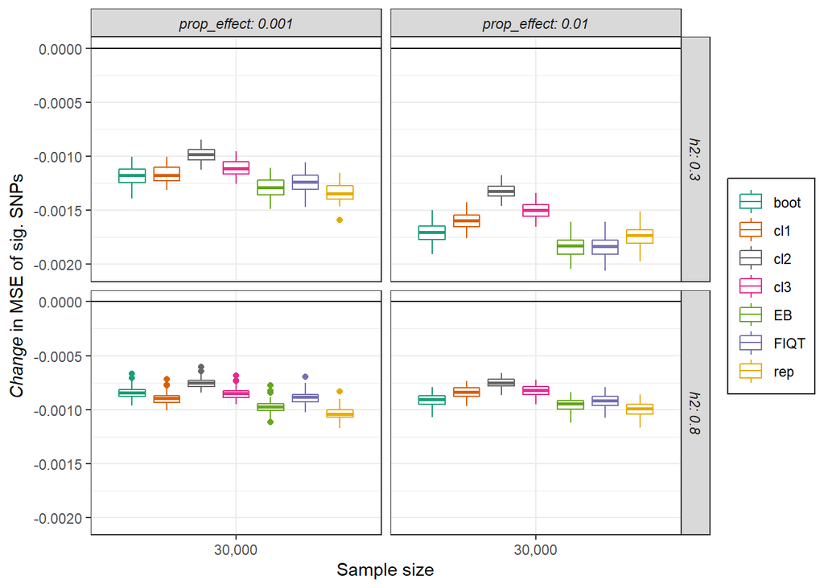

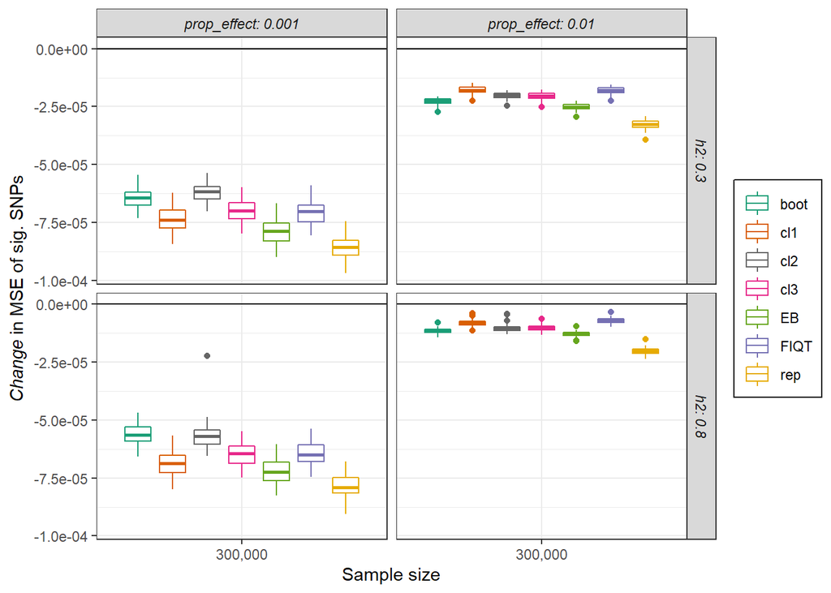

$~$ $~$ $~$ $~$

**Discussion:**

At the $5 \times 10^{-8}$ significance threshold for this bimodal effect size distribution, we see that the empirical Bayes method continues to perform well, with it always seeming to follow the same pattern as the ‘replication’ method in the plots. Our proposed bootstrap method behaves very competitively when the proportion of true effect SNPs is 0.01. Again, the simulations suggest that the conditional likelihood methods should not be employed to assist in reducing the bias induced by winner’s curse. The greater threshold shows similar results but with all change in MSE values negative for each method as anticipated at this threshold of $5 \times 10^{-4}$.

## Quantitative trait with skewed effect size distribution

We look at the $z$ vs $\text{bias}$ plots for Scenarios 15 and 16.

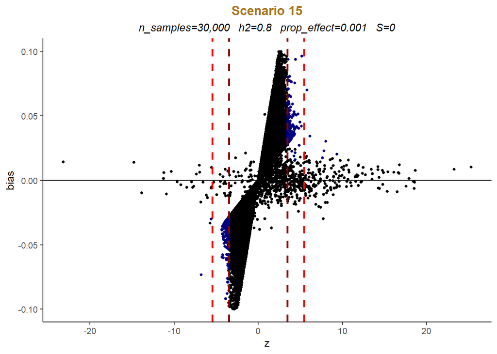

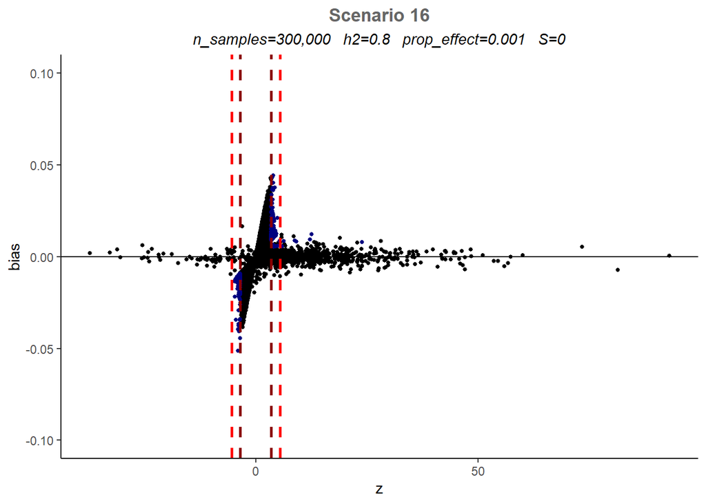

$~$ $~$

Results of using the first bias evaluation metric, `mse` with significance thresholds of $5 \times 10^{-8}$ and $5 \times 10^{-4}$, are detailed below.

**Evaluation metric 1 with threshold** $5 \times 10^{-8}$:

Summary of results for `mse` contained in `skew_5e-8_50sim_ave.csv`:

| Scenario | n_samples | h2 | prop_effect | S | EB | FIQT | boot | cl1 | cl2 | cl3 | rep |
| --- | --- | --- | --- | --- | --- | --- | --- | --- | --- | --- | --- |
| 1 | 30,000 | 0.3 | 0.010 | -1 | -0.000222 | -0.000095 | -0.000014 | 0.000641 | -0.000016 | 0.000256 | -0.000289 |
| 2 | 300,000 | 0.3 | 0.010 | -1 | -0.000003 | 0.000005 | 0.000000 | 0.000041 | 0.000020 | 0.000028 | -0.000003 |
| 3 | 30,000 | 0.8 | 0.010 | -1 | -0.000118 | -0.000023 | -0.000086 | 0.000481 | 0.000114 | 0.000262 | -0.000135 |
| 4 | 300,000 | 0.8 | 0.010 | -1 | -0.000001 | 0.000005 | 0.000001 | 0.000029 | 0.000017 | 0.000022 | -0.000002 |
| 5 | 30,000 | 0.3 | 0.001 | -1 | 0.000021 | 0.000163 | 0.000167 | 0.000396 | 0.000188 | 0.000271 | -0.000035 |
| 6 | 300,000 | 0.3 | 0.001 | -1 | 0.000000 | 0.000010 | 0.000011 | 0.000016 | 0.000010 | 0.000012 | 0.000000 |
| 7 | 30,000 | 0.8 | 0.001 | -1 | -0.000003 | 0.000134 | 0.000174 | 0.000291 | 0.000166 | 0.000215 | -0.000019 |
| 8 | 300,000 | 0.8 | 0.001 | -1 | 0.000001 | 0.000008 | 0.000009 | 0.000011 | 0.000007 | 0.000008 | 0.000000 |
| 9 | 30,000 | 0.3 | 0.010 | 0 | -0.000092 | -0.000067 | -0.000045 | 0.000185 | -0.000036 | 0.000054 | -0.000149 |
| 10 | 300,000 | 0.3 | 0.010 | 0 | -0.000002 | 0.000002 | 0.000000 | 0.000022 | 0.000011 | 0.000015 | -0.000002 |
| 11 | 30,000 | 0.8 | 0.010 | 0 | -0.000049 | 0.000007 | -0.000023 | 0.000275 | 0.000081 | 0.000160 | -0.000057 |
| 12 | 300,000 | 0.8 | 0.010 | 0 | -0.000001 | 0.000003 | 0.000001 | 0.000019 | 0.000010 | 0.000014 | -0.000001 |
| 13 | 30,000 | 0.3 | 0.001 | 0 | 0.000000 | 0.000095 | 0.000103 | 0.000237 | 0.000111 | 0.000162 | -0.000018 |
| 14 | 300,000 | 0.3 | 0.001 | 0 | 0.000000 | 0.000007 | 0.000008 | 0.000014 | 0.000008 | 0.000011 | 0.000000 |
| 15 | 30,000 | 0.8 | 0.001 | 0 | -0.000003 | 0.000076 | 0.000103 | 0.000181 | 0.000096 | 0.000129 | -0.000010 |
| 16 | 300,000 | 0.8 | 0.001 | 0 | 0.000001 | 0.000006 | 0.000008 | 0.000015 | 0.000008 | 0.000010 | -0.000001 |
| 17 | 30,000 | 0.3 | 0.010 | 1 | -0.000081 | -0.000052 | -0.000054 | 0.000171 | -0.000025 | 0.000054 | -0.000130 |
| 18 | 300,000 | 0.3 | 0.010 | 1 | -0.000001 | 0.000003 | 0.000000 | 0.000019 | 0.000010 | 0.000013 | -0.000002 |
| 19 | 30,000 | 0.8 | 0.010 | 1 | -0.000038 | 0.000011 | -0.000014 | 0.000236 | 0.000077 | 0.000142 | -0.000048 |
| 20 | 300,000 | 0.8 | 0.010 | 1 | -0.000001 | 0.000003 | 0.000001 | 0.000015 | 0.000008 | 0.000011 | -0.000001 |
| 21 | 30,000 | 0.3 | 0.001 | 1 | 0.000002 | 0.000078 | 0.000090 | 0.000182 | 0.000087 | 0.000125 | -0.000020 |
| 22 | 300,000 | 0.3 | 0.001 | 1 | 0.000000 | 0.000006 | 0.000007 | 0.000012 | 0.000007 | 0.000009 | 0.000000 |
| 23 | 30,000 | 0.8 | 0.001 | 1 | -0.000001 | 0.000071 | 0.000100 | 0.000139 | 0.000076 | 0.000101 | -0.000012 |
| 24 | 300,000 | 0.8 | 0.001 | 1 | 0.000000 | 0.000005 | 0.000007 | 0.000021 | 0.000007 | 0.000010 | -0.000001 |

$~$ $~$ $~$ $~$

The *mean* change in MSE over all significant SNPs across the 24 scenarios is obtained for each method:

```
##            EB          FIQT          boot           cl1           cl2
## -2.462500e-05  1.920833e-05  2.308333e-05  1.520417e-04  4.341667e-05
##           cl3           rep
##  8.725000e-05 -3.895833e-05
```

The methods are ranked according to the results above in ascending order:

```
##   EB FIQT boot  cl1  cl2  cl3  rep
##    2    3    4    7    5    6    1
```

$~$ $~$ $~$ $~$

*Change* in MSE over all significant SNPs due to method implementation, using a significance threshold of $5 \times 10^{-8}$:

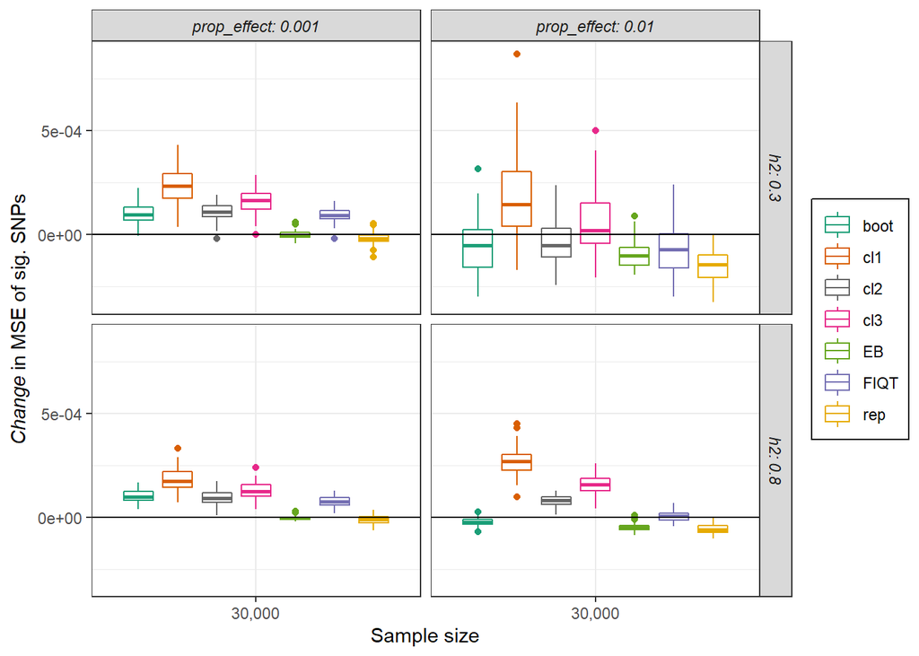

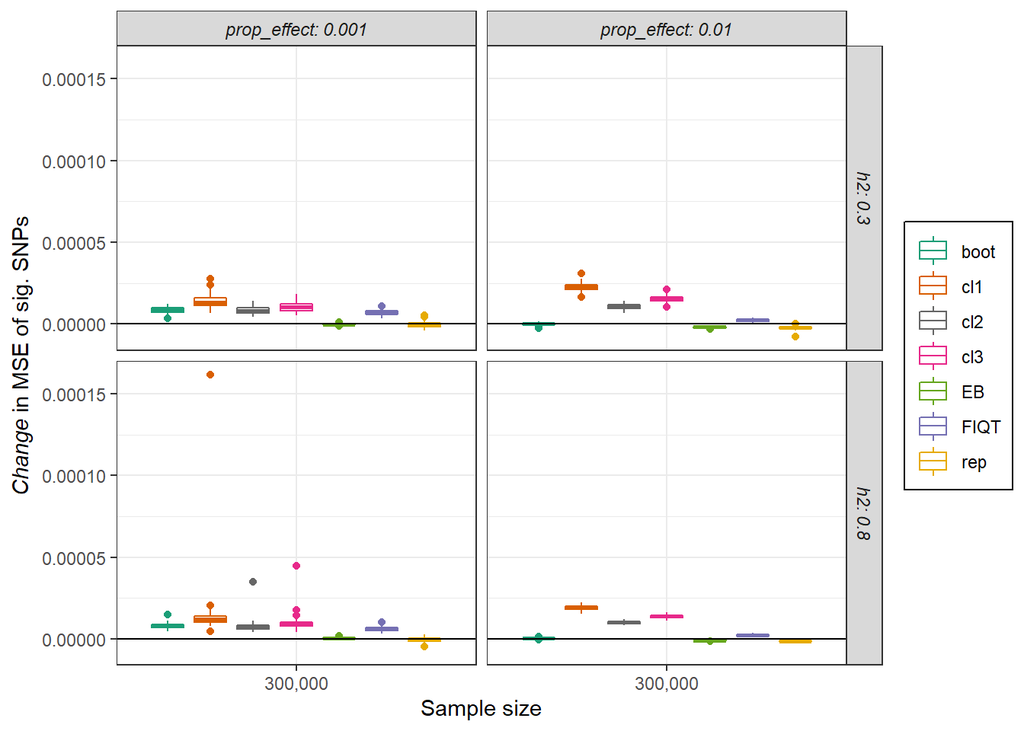

$~$ $~$ $~$ $~$

**Evaluation metric 1 with threshold** $5 \times 10^{-4}$:

Summary of results for `mse` contained in `skew_5e-4_50sim_ave.csv`:

| Scenario | n_samples | h2 | prop_effect | S | EB | FIQT | boot | cl1 | cl2 | cl3 | rep |
| --- | --- | --- | --- | --- | --- | --- | --- | --- | --- | --- | --- |
| 1 | 30,000 | 0.3 | 0.010 | -1 | -0.001585 | -0.001572 | -0.001491 | -0.001411 | -0.001208 | -0.001349 | -0.001600 |
| 2 | 300,000 | 0.3 | 0.010 | -1 | -0.000029 | -0.000018 | -0.000024 | -0.000021 | -0.000024 | -0.000025 | -0.000041 |
| 3 | 30,000 | 0.8 | 0.010 | -1 | -0.000856 | -0.000778 | -0.000792 | -0.000767 | -0.000716 | -0.000772 | -0.000981 |
| 4 | 300,000 | 0.8 | 0.010 | -1 | -0.000015 | -0.000006 | -0.000011 | -0.000009 | -0.000012 | -0.000012 | -0.000024 |
| 5 | 30,000 | 0.3 | 0.001 | -1 | -0.001366 | -0.001307 | -0.001215 | -0.001244 | -0.001047 | -0.001180 | -0.001430 |
| 6 | 300,000 | 0.3 | 0.001 | -1 | -0.000084 | -0.000075 | -0.000067 | -0.000079 | -0.000066 | -0.000075 | -0.000092 |
| 7 | 30,000 | 0.8 | 0.001 | -1 | -0.001082 | -0.000991 | -0.000901 | -0.001002 | -0.000841 | -0.000950 | -0.001156 |
| 8 | 300,000 | 0.8 | 0.001 | -1 | -0.000073 | -0.000067 | -0.000058 | -0.000071 | -0.000059 | -0.000067 | -0.000082 |
| 9 | 30,000 | 0.3 | 0.010 | 0 | -0.001544 | -0.001547 | -0.001438 | -0.001382 | -0.001158 | -0.001307 | -0.001537 |
| 10 | 300,000 | 0.3 | 0.010 | 0 | -0.000032 | -0.000026 | -0.000029 | -0.000028 | -0.000028 | -0.000030 | -0.000042 |
| 11 | 30,000 | 0.8 | 0.010 | 0 | -0.000864 | -0.000827 | -0.000804 | -0.000799 | -0.000705 | -0.000778 | -0.000951 |
| 12 | 300,000 | 0.8 | 0.010 | 0 | -0.000018 | -0.000012 | -0.000014 | -0.000014 | -0.000015 | -0.000015 | -0.000026 |
| 13 | 30,000 | 0.3 | 0.001 | 0 | -0.001404 | -0.001367 | -0.001257 | -0.001273 | -0.001059 | -0.001200 | -0.001428 |
| 14 | 300,000 | 0.3 | 0.001 | 0 | -0.000087 | -0.000080 | -0.000071 | -0.000082 | -0.000069 | -0.000078 | -0.000094 |
| 15 | 30,000 | 0.8 | 0.001 | 0 | -0.001153 | -0.001088 | -0.000986 | -0.001058 | -0.000884 | -0.001000 | -0.001204 |
| 16 | 300,000 | 0.8 | 0.001 | 0 | -0.000073 | -0.000069 | -0.000060 | -0.000071 | -0.000061 | -0.000068 | -0.000084 |
| 17 | 30,000 | 0.3 | 0.010 | 1 | -0.001516 | -0.001516 | -0.001405 | -0.001360 | -0.001137 | -0.001284 | -0.001509 |
| 18 | 300,000 | 0.3 | 0.010 | 1 | -0.000035 | -0.000030 | -0.000031 | -0.000032 | -0.000030 | -0.000033 | -0.000044 |
| 19 | 30,000 | 0.8 | 0.010 | 1 | -0.000845 | -0.000809 | -0.000780 | -0.000784 | -0.000683 | -0.000758 | -0.000930 |
| 20 | 300,000 | 0.8 | 0.010 | 1 | -0.000020 | -0.000015 | -0.000017 | -0.000018 | -0.000017 | -0.000019 | -0.000028 |
| 21 | 30,000 | 0.3 | 0.001 | 1 | -0.001463 | -0.001429 | -0.001305 | -0.001317 | -0.001089 | -0.001237 | -0.001461 |
| 22 | 300,000 | 0.3 | 0.001 | 1 | -0.000094 | -0.000088 | -0.000077 | -0.000088 | -0.000073 | -0.000083 | -0.000100 |
| 23 | 30,000 | 0.8 | 0.001 | 1 | -0.001192 | -0.001134 | -0.001019 | -0.001082 | -0.000900 | -0.001020 | -0.001221 |
| 24 | 300,000 | 0.8 | 0.001 | 1 | -0.000078 | -0.000076 | -0.000066 | -0.000072 | -0.000064 | -0.000071 | -0.000088 |

$~$ $~$ $~$ $~$